# Prophage-transformation conflict

Nicholas Croucher

2026-08-18

## Genetic analysis functions

# Analyse genotyping data

The species to be analysed are taken from those found to contribute to the burden of antimicrobial resistant-disease, as these constitute a set of genetically-diverse and well-sampled bacteria:

- *Escherichia coli*: Multiple MLST schemes available for [*Escherichia* spp.](https://pubmlst.org/bigsdb?db=pubmlst_escherichia_seqdef); the Achtman scheme was used, as it had 7 loci.
- *Staphylococcus aureus*: One MLST database available for [*S. aureus*](https://pubmlst.org/bigsdb?db=pubmlst_saureus_seqdef)
- *Klebsiella pneumoniae*: One MLST database available for [*K. pneumoniae*](https://bigsdb.pasteur.fr/cgi-bin/bigsdb/bigsdb.pl?db=pubmlst_klebsiella_seqdef)
- *Streptococcus pneumoniae*: One MLST database available for [*S. pneumoniae*](https://pubmlst.org/bigsdb?db=pubmlst_spneumoniae_seqdef)
- *Acinetobacter baumannii*: One MLST database available for [*A. baumanii*](https://pubmlst.org/bigsdb?db=pubmlst_abaumannii_seqdef)
- *Pseudomonas aeruginosa*: One MLST database available for [*P. aeruginosa*](https://pubmlst.org/bigsdb?db=pubmlst_paeruginosa_seqdef)
- *Mycobacterium tuberculosis*: Excluded, as low diversity means MLST is not informative for this species.
- *Enterococcus faecium*: One MLST database available for [*E. faecium*](https://pubmlst.org/bigsdb?db=pubmlst_efaecium_seqdef), although it is not clear whether other enterococci are effectively excluded, based on the species label in the profiles.
- *Enterobacter* spp.: One MLST database available for [*E. cloacae* and related species](https://pubmlst.org/bigsdb?db=pubmlst_ecloacae_seqdef).
- *Streptococcus agalactiae*: One MLST database available for [*S. agalactiae*](https://pubmlst.org/bigsdb?db=pubmlst_sagalactiae_seqdef).
- *Salmonella spp.*: Dominated by *S. enterica*. One MLST database available for [*S. enterica*](https://pubmlst.org/bigsdb?db=pubmlst_salmonella_seqdef).
- *Enterococcus faecalis*: One MLST database available for [*E. faecalis*](https://pubmlst.org/bigsdb?db=pubmlst_efaecalis_seqdef).
- *Proteus* spp.: One MLST database for [*Proteus* species](https://pubmlst.org/bigsdb?db=pubmlst_proteus_seqdef).
- *Serratia* spp.: One MLST database for [*Serratia* species](https://pubmlst.org/bigsdb?db=pubmlst_serratia_seqdef).
- *Streptococcus pyogenes*: One MLST database available for [*S. pyogenes*](https://pubmlst.org/bigsdb?db=pubmlst_spyogenes_seqdef).
- *Citrobacter* spp.: One MLST database available for [*C. freundii* and related species](https://pubmlst.org/bigsdb?db=pubmlst_cfreundii_seqdef).
- *Haemophilus influenzae*: One MLST database available for [*H. influenzae*](https://pubmlst.org/bigsdb?db=pubmlst_hinfluenzae_seqdef).
- *Shigella* spp.: Excluded as not evolutionary independent from *E. coli*.
- *Morganella morganii*: One MLST database available for [*M. morganii*](https://bigsdb.pasteur.fr/cgi-bin/bigsdb/bigsdb.pl?db=pubmlst_morganella_seqdef).

These were supplemented with other species representing genera [known to be naturally transformable](https://doi.org/10.1016/j.resmic.2007.09.004):

- *Agrobacterium tumefaciens*: Excluded, as no MLST data available.
- *Neisseria* spp.: One MLST database available for [*Neisseria* species](https://pubmlst.org/bigsdb?db=pubmlst_neisseria_seqdef); this can be included, as both *N. meningitidis* and *N. gonorrhoeae* are naturally transformable.
- *Legionella pneumophila*: Excluded, as no MLST data available from BigsDB.
- *Moraxella* spp.: One MLST database available for [*M. catarrhalis*](https://pubmlst.org/bigsdb?db=pubmlst_moraxella_seqdef); this can be included, as *Moraxella* species are generally regarded as transformable.
- *Vibrio cholerae*: One MLST database available for [*V. cholerae*](https://pubmlst.org/bigsdb?db=pubmlst_vcholerae_seqdef).
- *Campylobacter jejuni* & *coli*: One MLST database available for [*Campylobacter* spp.](https://pubmlst.org/bigsdb?db=pubmlst_campylobacter_seqdef). Both species are transformable, and therefore can be considered jointly.
- *Helicobacter pylori*: One MLST database available for [*H. pylori*](https://pubmlst.org/bigsdb?db=pubmlst_helicobacter_seqdef).
- *Mycobacterium smegmatis*: Excluded as no MLST scheme available.
- *Bacillus subtilis*: One MLST database available for [*B. subtilis*](https://pubmlst.org/bigsdb?db=pubmlst_bsubtilis_seqdef).

Searches run on 4/12/25.

```r
# Data structures
species_name <- list()
display_name <- list()
st_prefix <- list()
lower_length_threshold <- list()
upper_length_threshold <- list()
transformable <- list()
primary_niche <- list()
gram <- list()
intestinal <- list()

# E. coli
species_name[["Eco"]] = "Escherichia coli"
display_name[["Eco"]] = "italic('E. coli')"
st_prefix[["Eco"]] = "Eco_Achtman"
lower_length_threshold[["Eco"]] = 4000000
upper_length_threshold[["Eco"]] = 6500000
transformable[["Eco"]] = "Non-transformable"
primary_niche[["Eco"]] = "Gastrointestinal tract"
gram[["Eco"]] = "Diderm"
intestinal[["Eco"]] = "Intestinal"
# Citrobacter species
species_name[["Cit"]] = "Citrobacter spp"
display_name[["Cit"]] = "italic('Citrobacter')~'spp.'"
st_prefix[["Cit"]] = "Cit"
lower_length_threshold[["Cit"]] = 4000000
upper_length_threshold[["Cit"]] = 6500000
transformable[["Cit"]] = "Non-transformable"
primary_niche[["Cit"]] = "Gastrointestinal tract"
gram[["Cit"]] = "Diderm"
intestinal[["Cit"]] = "Intestinal"
# Enterobacter species
species_name[["Esp"]] = "Enterobacter spp"
display_name[["Esp"]] = "italic('Enterobacter')~'spp.'"
st_prefix[["Esp"]] = "Esp"
lower_length_threshold[["Esp"]] = 4000000
upper_length_threshold[["Esp"]] = 6500000
transformable[["Esp"]] = "Non-transformable"
primary_niche[["Esp"]] = "Gastrointestinal tract"
gram[["Esp"]] = "Diderm"
intestinal[["Esp"]] = "Intestinal"
# Proteus species
species_name[["Psp"]] = "Proteus spp"
display_name[["Psp"]] = "italic('Proteus')~'spp.'"
st_prefix[["Psp"]] = "Psp"
lower_length_threshold[["Psp"]] = 3000000
upper_length_threshold[["Psp"]] = 5000000
transformable[["Psp"]] = "Non-transformable"
primary_niche[["Psp"]] = "Gastrointestinal tract"
gram[["Psp"]] = "Diderm"
intestinal[["Psp"]] = "Intestinal"
# Serratia species
species_name[["Ssp"]] = "Serratia spp"
display_name[["Ssp"]] = "italic('Serratia')~'spp.'"
st_prefix[["Ssp"]] = "Ssp"
lower_length_threshold[["Ssp"]] = 4000000
upper_length_threshold[["Ssp"]] = 6500000
transformable[["Ssp"]] = "Non-transformable"
primary_niche[["Ssp"]] = "Gastrointestinal tract"
gram[["Ssp"]] = "Diderm"
intestinal[["Ssp"]] = "Intestinal"
# S. aureus
species_name[["Sau"]] = "Staphylococcus aureus"
display_name[["Sau"]] = "italic('S. aureus')"
st_prefix[["Sau"]] = "Sau"
lower_length_threshold[["Sau"]] = 2000000
upper_length_threshold[["Sau"]] = 4000000
transformable[["Sau"]] = "Non-transformable"
primary_niche[["Sau"]] = "Multiple"
gram[["Sau"]] = "Monoderm"
intestinal[["Sau"]] = "Non-intestinal"
# K. pneumoniae
species_name[["Kpn"]] = "Klebsiella pneumoniae"
display_name[["Kpn"]] = "italic('K. pneumoniae')"
st_prefix[["Kpn"]] = "Kpn"
lower_length_threshold[["Kpn"]] = 4000000
upper_length_threshold[["Kpn"]] = 7000000
transformable[["Kpn"]] = "Non-transformable"
primary_niche[["Kpn"]] = "Gastrointestinal tract"
gram[["Kpn"]] = "Diderm"
intestinal[["Kpn"]] = "Intestinal"
# S. pneumoniae
species_name[["Spn"]] = "Streptococcus pneumoniae"
display_name[["Spn"]] = "italic('S. pneumoniae')"
st_prefix[["Spn"]] = "Spn"
lower_length_threshold[["Spn"]] = 1500000
upper_length_threshold[["Spn"]] = 3000000
transformable[["Spn"]] = "Transformable"
primary_niche[["Spn"]] = "Respiratory tract"
gram[["Spn"]] = "Monoderm"
intestinal[["Spn"]] = "Non-intestinal"
# A. baumanii
species_name[["Abau"]] = "Acinetobacter baumannii"
display_name[["Abau"]] = "italic('A. baumannii')"
st_prefix[["Abau"]] = "Abau_Oxford"
lower_length_threshold[["Abau"]] = 3000000
upper_length_threshold[["Abau"]] = 5500000
transformable[["Abau"]] = "Transformable"
primary_niche[["Abau"]] = "Environmental"
gram[["Abau"]] = "Diderm"
intestinal[["Abau"]] = "Non-intestinal"
# P. aeruginosa
species_name[["Pae"]] = "Pseudomonas aeruginosa"
display_name[["Pae"]] = "italic('P. aeruginosa')"
st_prefix[["Pae"]] = "Pae"
lower_length_threshold[["Pae"]] = 5500000
upper_length_threshold[["Pae"]] = 8500000
transformable[["Pae"]] = "Transformable"
primary_niche[["Pae"]] = "Environmental"
gram[["Pae"]] = "Diderm"
intestinal[["Pae"]] = "Non-intestinal"
# E. faecium
species_name[["Efm"]] = "Enterococcus faecium"
display_name[["Efm"]] = "italic('E. faecium')"
st_prefix[["Efm"]] = "Efm"
lower_length_threshold[["Efm"]] = 1500000
upper_length_threshold[["Efm"]] = 4000000
transformable[["Efm"]] = "Non-transformable"
primary_niche[["Efm"]] = "Gastrointestinal tract"
gram[["Efm"]] = "Monoderm"
intestinal[["Efm"]] = "Intestinal"
# S. agalactiae
species_name[["Sag"]] = "Streptococcus agalactiae"
display_name[["Sag"]] = "italic('S. agalactiae')"
st_prefix[["Sag"]] = "Sag"
lower_length_threshold[["Sag"]] = 1500000
upper_length_threshold[["Sag"]] = 3000000
transformable[["Sag"]] = "Non-transformable"
primary_niche[["Sag"]] = "Multiple"
gram[["Sag"]] = "Monoderm"
intestinal[["Sag"]] = "Intestinal"
# S. enterica
species_name[["Sen"]] = "Salmonella enterica"
display_name[["Sen"]] = "italic('S. enterica')"
st_prefix[["Sen"]] = "Sen"
lower_length_threshold[["Sen"]] = 3500000
upper_length_threshold[["Sen"]] = 6000000
transformable[["Sen"]] = "Non-transformable"
primary_niche[["Sen"]] = "Gastrointestinal tract"
gram[["Sen"]] = "Diderm"
intestinal[["Sen"]] = "Intestinal"
# E. faecalis
species_name[["Efs"]] = "Enterococcus faecalis"
display_name[["Efs"]] = "italic('E. faecalis')"
st_prefix[["Efs"]] = "Efs" # not run
lower_length_threshold[["Efs"]] = 2000000
upper_length_threshold[["Efs"]] = 4000000
transformable[["Efs"]] = "Non-transformable"
primary_niche[["Efs"]] = "Gastrointestinal tract"
gram[["Efs"]] = "Monoderm"
intestinal[["Efs"]] = "Intestinal"
# S. pyogenes
species_name[["Spy"]] = "Streptococcus pyogenes"
display_name[["Spy"]] = "italic('S. pyogenes')"
st_prefix[["Spy"]] = "Spy"
lower_length_threshold[["Spy"]] = 1000000
upper_length_threshold[["Spy"]] = 2500000
transformable[["Spy"]] = "Non-transformable"
primary_niche[["Spy"]] = "Respiratory tract"
gram[["Spy"]] = "Monoderm"
intestinal[["Spy"]] = "Non-intestinal"
# H. influenzae
species_name[["Hflu"]] = "Haemophilus influenzae"
display_name[["Hflu"]] = "italic('H. influenzae')"
st_prefix[["Hflu"]] = "Hflu"
lower_length_threshold[["Hflu"]] = 1000000
upper_length_threshold[["Hflu"]] = 2500000
transformable[["Hflu"]] = "Transformable"
primary_niche[["Hflu"]] = "Respiratory tract"
gram[["Hflu"]] = "Diderm"
intestinal[["Hflu"]] = "Non-intestinal"
# M. morganii
species_name[["Mmo"]] = "Morganella morganii"
display_name[["Mmo"]] = "italic('M. morganii')"
st_prefix[["Mmo"]] = "Mmo"
lower_length_threshold[["Mmo"]] = 3000000
upper_length_threshold[["Mmo"]] = 5000000
transformable[["Mmo"]] = "Non-transformable"
primary_niche[["Mmo"]] = "Gastrointestinal tract"
gram[["Mmo"]] = "Diderm"
intestinal[["Mmo"]] = "Intestinal"
# Neisseria species
species_name[["Nsp"]] = "Neisseria spp"
display_name[["Nsp"]] = "italic('Neisseria')~'spp.'"
st_prefix[["Nsp"]] = "Nsp"
lower_length_threshold[["Nsp"]] = 1500000
upper_length_threshold[["Nsp"]] = 3000000
transformable[["Nsp"]] = "Transformable"
primary_niche[["Nsp"]] = "Multiple"
gram[["Nsp"]] = "Diderm"
intestinal[["Nsp"]] = "Non-intestinal"
# Moraxella species
species_name[["Msp"]] = "Moraxella catarrhalis"
display_name[["Msp"]] = "italic('Moraxella')~'spp.'"
st_prefix[["Msp"]] = "Msp"
lower_length_threshold[["Msp"]] = 1000000
upper_length_threshold[["Msp"]] = 3000000
transformable[["Msp"]] = "Transformable"
primary_niche[["Msp"]] = "Respiratory tract"
gram[["Msp"]] = "Diderm"
intestinal[["Msp"]] = "Non-intestinal"
# Campylobacter species
species_name[["Cam"]] = "Campylobacter spp"
display_name[["Cam"]] = "italic('Campylobacter')~'spp.'"
st_prefix[["Cam"]] = "Cam"
lower_length_threshold[["Cam"]] = 1000000
upper_length_threshold[["Cam"]] = 3000000
transformable[["Cam"]] = "Transformable"
primary_niche[["Cam"]] = "Gastrointestinal tract"
gram[["Cam"]] = "Diderm"
intestinal[["Cam"]] = "Intestinal"
# Helicobacter pylori
species_name[["Hpy"]] = "Helicobacter pylori"
display_name[["Hpy"]] = "italic('H. pylori')"
st_prefix[["Hpy"]] = "Hpy"
lower_length_threshold[["Hpy"]] = 1000000
upper_length_threshold[["Hpy"]] = 2500000
transformable[["Hpy"]] = "Transformable"
primary_niche[["Hpy"]] = "Gastrointestinal tract"
gram[["Hpy"]] = "Diderm"
intestinal[["Hpy"]] = "Non-intestinal"
# Vibrio cholerae
species_name[["Vch"]] = "Vibrio cholerae"
display_name[["Vch"]] = "italic('V. cholerae')"
st_prefix[["Vch"]] = "Vch"
lower_length_threshold[["Vch"]] = 3000000
upper_length_threshold[["Vch"]] = 5000000
transformable[["Vch"]] = "Transformable"
primary_niche[["Vch"]] = "Environmental"
gram[["Vch"]] = "Diderm"
intestinal[["Vch"]] = "Non-intestinal"
# Bacillus subtilis
species_name[["Bsu"]] = "Bacillus subtilis"
display_name[["Bsu"]] = "italic('B. subtilis')"
st_prefix[["Bsu"]] = "Bsu"
lower_length_threshold[["Bsu"]] = 3000000
upper_length_threshold[["Bsu"]] = 5500000
transformable[["Bsu"]] = "Transformable"
primary_niche[["Bsu"]] = "Environmental"
gram[["Bsu"]] = "Monoderm"
intestinal[["Bsu"]] = "Non-intestinal"
```

### Calculate MSTs from MLST data

```r
mlst_profiles <- list()
mlst_msts <- list()
slvs <- list()
mst_plots <- list()

for (name in rev(names(st_prefix))) {

  message(paste("Processing",name))

  mlst_profiles[[name]] <-
    read.table(paste0("./MLST_data/",st_prefix[[name]],".tab.txt"),
               sep = "\t", header = TRUE) %>%
      dplyr::select(-dplyr::any_of(c("clonal_complex","species")))

  mlst_msts[[name]] <-
    generate_mst_from_mlst(mlst_profiles[[name]])

  slvs[[name]] <- as_data_frame(mlst_msts[[name]], what = "edges")

  mst_plots[[name]] <- plot_mst(mlst_msts[[name]])

  ggsave(paste0("./ebursts/",name,"_eburst.png"),
       mst_plots[[name]],
       width = 8,
       height = 8)

}

# Get summaries of MLST data
st_counts_df <-
  enframe(mlst_profiles) %>%
    dplyr::mutate(`Sequence types` =
                    map_int(value, nrow)) %>%  # count rows in each df
    dplyr::select(name, `Sequence types`) %>%
    dplyr::left_join(enframe(species_name) %>%
                       tidyr::unnest(value),
                     by = "name") %>%
    dplyr::mutate(name = value) %>%
    dplyr::select(-value)

write_csv(
  st_counts_df,
  file = "./MLST_data/st_counts.csv"
)
```

### Calculate mismatches between SLVs

```r
mismatches <- list()

for (name in rev(names(st_prefix))) {

  mismatches[[name]] <-
    identify_mismatches_between_slvs(mlst_profiles[[name]],
                                     slvs[[name]],
                                     fn = paste0("./MLST_sequences/",st_prefix[[name]],"_*.fas")
    )

}

mismatches_df <-
  dplyr::bind_rows(mismatches,.id = "Species")

write_csv(
  mismatches_df,
  file = "./MLST_data/mismatches.csv"
)

write_csv(
  mismatches_df %>%
    dplyr::select(Species,seq_from_id,seq_to_id,mismatches) %>%
    dplyr::distinct() %>%
    tidyr::unnest(mismatches),
  file = "./MLST_data/mismatch_details.csv"
)
```

Plot number of mismatches between SLV diverged alleles:

```r
mismatches_df <-
  read_csv("./MLST_data/mismatches.csv") %>%
    dplyr::select(-mismatches) %>%
    dplyr::left_join(
      read_csv("./MLST_data/mismatch_details.csv") %>%
        tidyr::nest(data = c("pos","base_from","base_to")) %>%
        dplyr::rename(mismatches = data),
      by = c("Species","seq_from_id","seq_to_id")
    ) %>%
        dplyr::left_join(enframe(display_name) %>%
                           tidyr::unnest(value) %>%
                           dplyr::rename(display = value),
                             by = c("Species" = "name"))
```

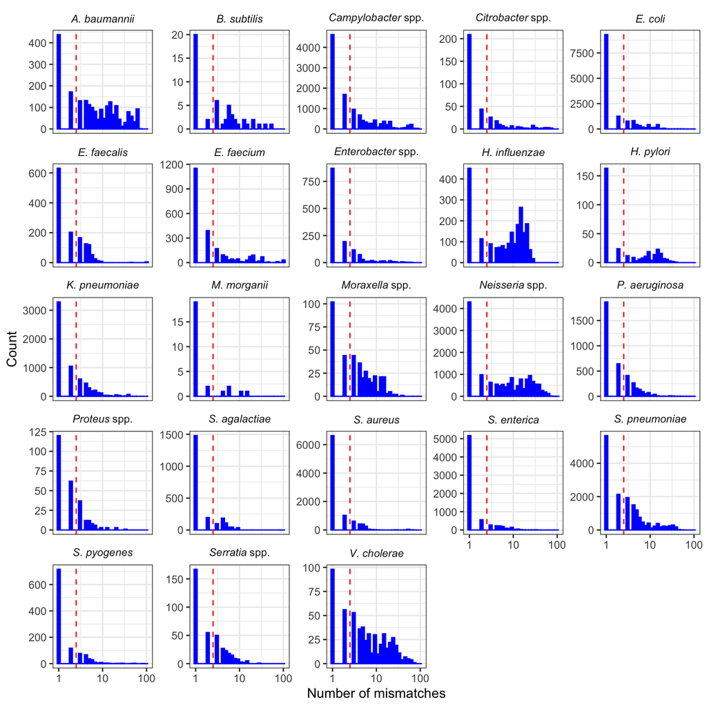

```r
ggplot(mismatches_df,
       aes(x = n_mismatch)) +
  geom_histogram(colour = "blue",fill = "blue") +
  scale_x_continuous(trans = "log10") +
  geom_vline(xintercept = 2.5, col = 'red', linetype = 2) +
  facet_wrap(~display,
             scales = 'free_y',
             labeller = label_parsed) +
  ylab("Count") +
  xlab("Number of mismatches") +
  theme_bw() +
  theme(strip.background = element_blank())
```

### Calculate r/m statistics

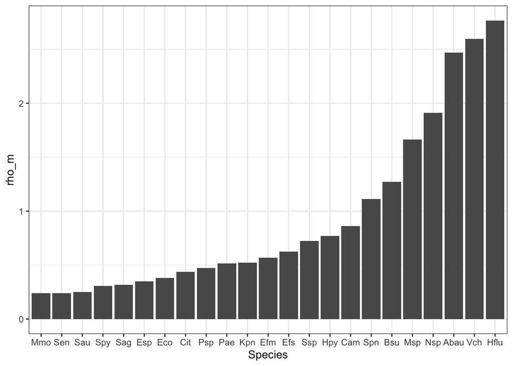

```r
rho_m_df <-
  mismatches_df %>%
        dplyr::filter(!is.na(Classification)) %>%
        dplyr::group_by(Species) %>%
        dplyr::summarise(rho_m = sum(Classification=="Recombination")/sum(Classification=="Point mutation")) %>%
        dplyr::ungroup()

species_levels <-
  rho_m_df %>%
    dplyr::arrange(rho_m) %>%
    dplyr::pull(Species)

rho_m_df %<>%
  dplyr::mutate(Species = factor(Species, levels = species_levels))

ggplot(rho_m_df,
        aes(x = Species,
            y = rho_m)) +
  geom_col() +
  theme_bw()
```

### Fit generalised linear mixed effects model of homologous recombination

```r
rec_modelling_df <-
  mismatches_df %>%
    dplyr::filter(!is_invalid) %>%
    dplyr::select(Species,locus,Classification) %>%
    dplyr::mutate(Locus = paste0(Species,"_",locus)) %>%
    dplyr::select(-locus) %>%
    dplyr::group_by(Species) %>%
    dplyr::mutate(n_loci = n_distinct(Locus)) %>%
    dplyr::ungroup() %>%
    dplyr::mutate(FPR = (1/n_loci)**2) %>%
    dplyr::group_by(Species,Locus,FPR) %>%
    dplyr::summarise(Count = n(),
                     Rec_count = sum(Classification == "Recombination")) %>%
    dplyr::ungroup() %>%
    dplyr::mutate(`Recombination proportion` = Rec_count/Count)
rec_probability_model <-
  glmmTMB::glmmTMB(
    `Recombination proportion` ~ Species + (1|Locus),
    data = rec_modelling_df,
    family = betabinomial(link = "logit"),
    ziformula = ~0,
    dispformula = ~1,
    weights = Count
  )

performance::check_model(rec_probability_model)
```

```
## `check_outliers()` does not yet support models of class `glmmTMB`.
```

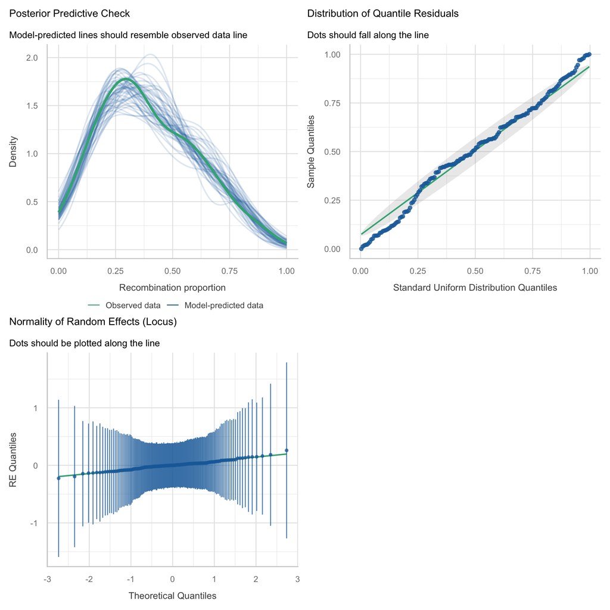

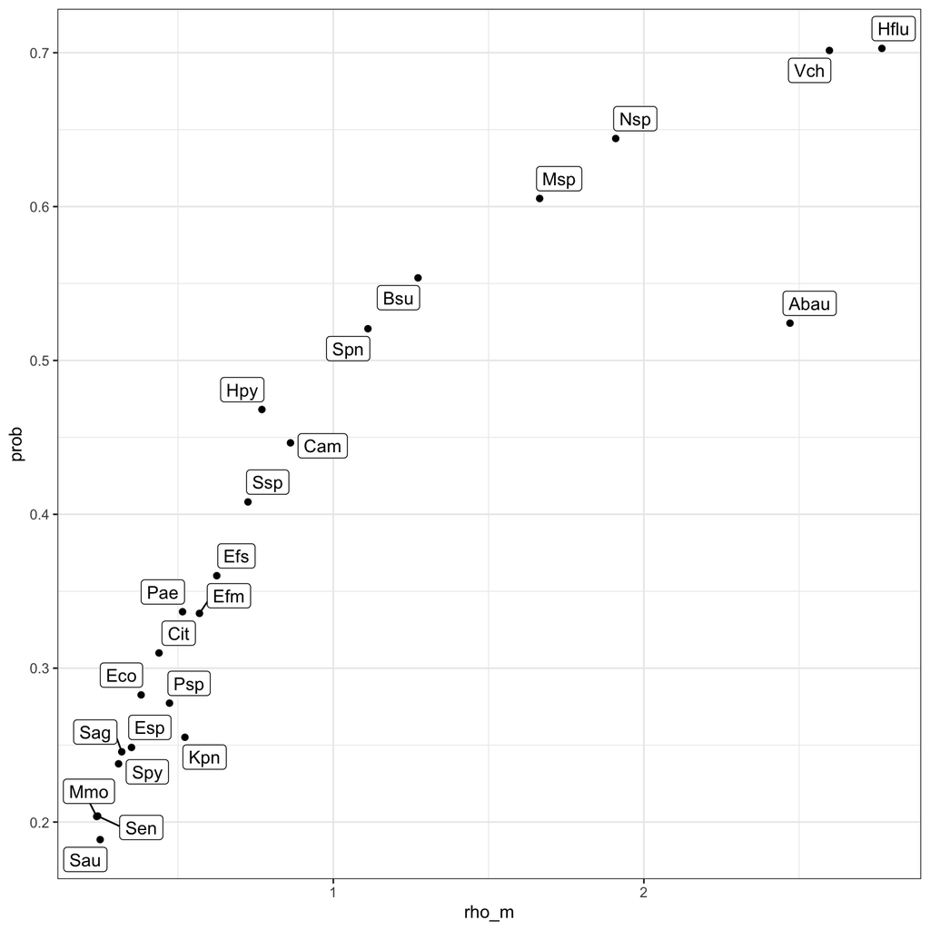

```r
# Estimated marginal means per species on the response scale (probabilities)
rec_prob_df <-
  emmeans(
    rec_probability_model,
    specs  = ~ Species,
    type   = "response"  # back-transform from logit to probability
  ) %>%
  tibble::as_tibble()

combined_rec_output_df <-
  rec_prob_df %>%
    dplyr::left_join(rho_m_df, by = "Species")

ggplot(combined_rec_output_df,
       aes(x = rho_m,
           y = prob)) +
  geom_point() +
  ggrepel::geom_label_repel(aes(label = Species)) +
  theme_bw()
```

# Prophage data

## Search for complete genomes from target sequences

Searches run on 8/12/25. For multispecies datasets, the species were selected as the binomial names that were more common than the count of isolates within the genus with an undefined species name.

```bash
cd prophage
conda activate edirect
for SPECIES in "Escherichia coli" "Staphylococcus aureus" "Klebsiella pneumoniae" "Streptococcus pneumoniae" "Acinetobacter baumanii"   "Pseudomonas aeruginosa" "Enterococcus faecium"    "Streptococcus agalactiae" "Salmonella enterica" "Enterococcus faecalis"    "Streptococcus pyogenes"   "Haemophilus influenzae" "Morganella morganii"      "Neisseria meningitidis" "Neisseria gonorrhoeae" "Moraxella catarrhalis" "Campylobacter jejuni"     "Helicobacter pylori"      "Vibrio cholerae" "Bacillus subtilis" "Serratia sarumanii" "Serratia ureilytica" "Serratia nevei" "Serratia nematodiphila" "Serratia bockelmannii" "Serratia liquefaciens" "Serratia fonticola" "Serratia marcescens" "Serratia plymuthica" "Proteus mirabilis" "Proteus terrae" "Enterobacter hormaechei" "Citrobacter freundii";
  do echo "Processing $SPECIES";
  SEARCH_STRING=`echo "\"$SPECIES\"[Organism] AND \"latest refseq\"[filter] AND complete_genome[filter] AND (all[filter] NOT anomalous[filter])"`
  esearch -db assembly -query "$SEARCH_STRING" | elink -target nuccore -name assembly_nuccore_refseq | esummary | xtract -pattern DocumentSummary -element AccessionVersion | sort -u > ${SPECIES}_nuccore_complete.txt;
  ./get_prophage_data.sh ${SPECIES}_nuccore_complete.txt ${SPECIES};
done
# Combine multispecies datasets
cat Neisseria\ gonorrhoeae_nuccore_complete.txt Neisseria\ meningitidis_nuccore_complete.txt > ./prophage/Neisseria\ spp_nuccore_complete.txt
cat Campylobacter\ coli_nuccore_complete.txt Campylobacter\ jejuni_nuccore_complete.txt > Campylobacter\ spp_nuccore_complete.txt
cat Serratia*_nuccore_complete.txt > Serratia\ spp_nuccore_complete.txt
cat Proteus*_nuccore_complete.txt > Proteus\ spp_nuccore_complete.txt
cat Enterobacter*_nuccore_complete.txt > Enterobacter\ spp_nuccore_complete.txt
cat Citrobacter*_nuccore_complete.txt > Citrobacter\ spp_nuccore_complete.txt
```

## Search for PHASTER results

```r
phaster_df <-
  read_csv("./phaster_outputs/phaster_precomputed_accessions.csv")
```

```r
complete_sequences_df <-
  map_dfr(species_name, ~ {
  # Create filename
  filename <- paste0("./prophage/",str_c(str_replace_all(.x, " ", "\\ "), "_nuccore_complete.txt"))
  # Read file if it exists
  if (file.exists(filename)) {
    read_tsv(filename, col_names = "data", col_types = "c") %>%
      mutate(species =.x)
  } else {
    tibble(data = character(0), species =.x)
  }
}) %>%
  dplyr::filter(
      # Include only complete genomes (shorter accession numbers)
      str_detect(data, "^[A-Z]{2}\\d{4,8}\\.\\d+$")
  ) %>%
  dplyr::mutate(
    # Extract components from data column
    accession_base = str_extract(data, "^[A-Z]{2}\\d+"),
    full_accession = data
  )

phaster_complete_sequences_df <-
  complete_sequences_df %>%
    # Try exact match first
    dplyr::left_join(
      phaster_df %>%
        dplyr::select(accession, submission_url:summary_url),
      by = c("full_accession" = "accession")
    ) %>%
    # For unmatched, try base accession match
    dplyr::left_join(
      phaster_df %>%
        dplyr::mutate(accession_base = str_extract(accession, "^[A-Z]{2}\\d+")) %>%
        dplyr::select(accession_base, accession, submission_url:summary_url) %>%
        dplyr::distinct(accession_base,.keep_all = TRUE),
      by = "accession_base",
      suffix = c("", "_base")
    ) %>%
    # Coalesce to prioritize exact matches
    dplyr::mutate(
      matched_accession = coalesce(accession, accession_base),
      final_submission_url = coalesce(submission_url, submission_url_base),
      final_zip_url = coalesce(zip_url, zip_url_base),
      final_summary_url = coalesce(summary_url, summary_url_base)
    ) %>%
    dplyr::select(
      data,
      species,
      matched_accession,
      submission_url = final_submission_url,
      zip_url = final_zip_url,
      summary_url = final_summary_url
    ) %>%
    dplyr::filter(!is.na(submission_url))

# Export your accessions to a text file
write.csv(
  phaster_complete_sequences_df %>%
    dplyr::pull(data),
    file = "prophage/phaster_accessions.txt",
    quote = F,
    row.names = F,
    col.names = FALSE)
```

```bash
cd prophage
./get_phaster_ncbi_info.sh
```

### Parse genome lengths

```r
seq_length_df <-
  read.table("./prophage/phaster_metadata.tsv",
             sep = "\t",
             comment.char = "",
             header = TRUE) %>%
    dplyr::left_join(phaster_complete_sequences_df,
                     by = c("Accession"="data")) %>%
    dplyr::group_by(species,BioSampleAccession) %>%
    dplyr::mutate(Total_length = sum(SequenceLength)) %>%
    dplyr::ungroup() %>%
    dplyr::left_join(
      enframe(lower_length_threshold) %>%
            tidyr::unnest(value) %>%
            dplyr::rename(Lower = value) %>%
        dplyr::left_join(
        enframe(upper_length_threshold) %>%
            tidyr::unnest(value) %>%
            dplyr::rename(Upper = value)
        ) %>%
        dplyr::left_join(enframe(species_name) %>%
                           tidyr::unnest(value) %>%
                           dplyr::rename(species = value),
                             by = "name") %>%
        dplyr::left_join(enframe(display_name) %>%
                           tidyr::unnest(value) %>%
                           dplyr::rename(display = value),
                             by = "name")
      ) %>%
      dplyr::filter(!is.na(name))
```

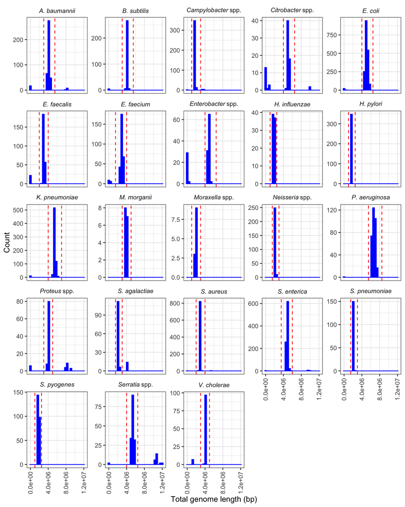

```r
# Plot genome lengths and boundaries
ggplot(seq_length_df,
       aes(x = Total_length)) +
  geom_histogram(colour = "blue", fill = "blue") +
  geom_vline(data = seq_length_df %>%
               dplyr::select(display, Upper) %>%
               dplyr::distinct(),
             aes(xintercept = Upper),
             colour = "red", linetype = 2) +
  geom_vline(data = seq_length_df %>%
               dplyr::select(display, Lower) %>%
               dplyr::distinct(),
             aes(xintercept = Lower),
             colour = "red", linetype = 2) +
  facet_wrap(~display,
             scales = 'free_y',
             labeller = label_parsed) +
  ylab("Count") +
  xlab("Total genome length (bp)") +
  theme_bw() +
  theme(strip.background = element_blank(),
        axis.text.x = element_text(angle = 90, hjust = 1, vjust = 0.5))
```

```r
filtered_genome_df <-
  seq_length_df %>%
    dplyr::filter(Total_length >= Lower & Total_length <= Upper)

write.table(filtered_genome_df %>%
            dplyr::mutate(summary_url = gsub("/submissions/","/jobs/",summary_url)) %>%
            dplyr::select(summary_url),
          file = "./phaster_outputs/phaster_urls.list",
          row.names = FALSE,
          col.names = FALSE,
          quote = FALSE)
```

Each dataset was then retrieved from the database:

```bash
cd phaster_outputs
./download_phaster.sh
```

```r
parse_phaster_summary <- function(file, accession) {
  # If file missing or empty, return nothing
  if (!file.exists(file)) return(NULL)
  lines <- readr::read_lines(file)
  if (length(lines) == 0) return(NULL)

  # Find header line
  header_idx <- which(str_detect(lines, "^\\s*REGION\\s+REGION_LENGTH"))
  if (length(header_idx) == 0) return(NULL)

  # Find dashed separator after header
  sep_idx <- header_idx + 1
  while (sep_idx <= length(lines) && !str_detect(lines[sep_idx], "-{5,}")) {
    sep_idx <- sep_idx + 1
  }
  if (sep_idx > length(lines)) return(NULL)

  data_start <- sep_idx + 1

  # Data lines
  data_lines <- lines[data_start:length(lines)]
  data_lines <- data_lines[data_lines != ""]
  if (length(data_lines) == 0) return(NULL)

  # --- line parser using whitespace ---
  parse_line <- function(x) {
    parts <- x %>%
      str_squish() %>%
      str_split("\\s+", simplify = TRUE) %>%
      as.character()

    if (length(parts) < 16) return(NULL)

    region        <- parts[1]
    region_length <- parts[2]
    completeness  <- parts[3]

    rest <- parts[-(1:3)]
    if (length(rest) == 0) return(NULL)

    # REGION_POSITION looks like "start-end"
    pos_idx <- which(str_detect(rest, "^[0-9]+-[0-9]+$"))[1]
    if (is.na(pos_idx)) return(NULL)

    # SPECIFIC_KEYWORD = everything before REGION_POSITION
    specific_keyword <-
      if (pos_idx == 1) NA_character_
      else paste(rest[1:(pos_idx - 1)], collapse = " ")

    tail_tokens <- rest[pos_idx:length(rest)]
    if (length(tail_tokens) < 13) return(NULL)

    tibble(
      REGION                    = region,
      REGION_LENGTH             = region_length,
      COMPLETENESS_SCORE        = completeness,
      SPECIFIC_KEYWORD          = specific_keyword,
      REGION_POSITION           = tail_tokens[1],
      TRNA_NUM                  = tail_tokens[2],
      TOTAL_PROTEIN_NUM         = tail_tokens[3],
      PHAGE_HIT_PROTEIN_NUM     = tail_tokens[4],
      HYPOTHETICAL_PROTEIN_NUM  = tail_tokens[5],
      PHAGE_HYPO_PERCENT        = tail_tokens[6],
      BACTERIAL_PROTEIN_NUM     = tail_tokens[7],
      ATT_SITE_SHOWUP           = tail_tokens[8],
      PHAGE_SPECIES_NUM         = tail_tokens[9],
      MOST_COMMON_PHAGE_NAME    = tail_tokens[10],
      MOST_COMMON_PHAGE_NUM     = tail_tokens[11],
      MOST_COMMON_PHAGE_PERCENT = tail_tokens[12],
      GC_PERCENTAGE             = tail_tokens[13]
    )
  }

  df <- map_dfr(data_lines, parse_line)
  if (!("REGION" %in% names(df)) || nrow(df) == 0) return(NULL)

  # ---------- clean types, keep all regions ----------
  clean_df <- df %>%
    filter(str_detect(REGION, "^\\d+$")) %>%
    mutate(
      REGION              = as.integer(REGION),
      REGION_LENGTH_Kb    = as.numeric(str_remove(REGION_LENGTH, "Kb")),
      COMPLETENESS        = str_extract(COMPLETENESS_SCORE, "^[^()]+") %>% str_trim(),
      SCORE               = str_extract(COMPLETENESS_SCORE, "(?<=\\()\\d+(?=\\))") %>% as.integer(),
      TOTAL_PROTEIN_NUM   = as.integer(TOTAL_PROTEIN_NUM),
      TRNA_NUM            = as.integer(TRNA_NUM),
      PHAGE_HIT_PROTEIN_NUM    = as.integer(PHAGE_HIT_PROTEIN_NUM),
      HYPOTHETICAL_PROTEIN_NUM = as.integer(HYPOTHETICAL_PROTEIN_NUM),
      PHAGE_HYPO_PERCENT       = as.numeric(str_remove(PHAGE_HYPO_PERCENT, "%")),
      BACTERIAL_PROTEIN_NUM    = as.integer(BACTERIAL_PROTEIN_NUM),
      PHAGE_SPECIES_NUM        = as.integer(PHAGE_SPECIES_NUM),
      MOST_COMMON_PHAGE_NUM    = as.integer(MOST_COMMON_PHAGE_NUM),
      MOST_COMMON_PHAGE_PERCENT = as.numeric(str_remove(MOST_COMMON_PHAGE_PERCENT, "%")),
      GC_PERCENTAGE            = as.numeric(str_remove(GC_PERCENTAGE, "%"))
    )

  if (nrow(clean_df) == 0) return(NULL)

  # ---------- keywords → long ----------
  keywords_long <- clean_df %>%
    mutate(SPECIFIC_KEYWORD = coalesce(SPECIFIC_KEYWORD, "")) %>%
    separate_rows(SPECIFIC_KEYWORD, sep = ",") %>%
    mutate(
      SPECIFIC_KEYWORD = str_trim(SPECIFIC_KEYWORD),
      SPECIFIC_KEYWORD = na_if(SPECIFIC_KEYWORD, "")
    ) %>%
    filter(!is.na(SPECIFIC_KEYWORD))

  # No keywords at all in this file: return regions without keyword columns
  if (nrow(keywords_long) == 0) {
    out <- clean_df %>%
      transmute(
        accession,
        REGION,
        REGION_LENGTH_Kb,
        TOTAL_PROTEIN_NUM,
        PHAGE_HIT_PROTEIN_NUM,
        COMPLETENESS,
        SCORE,
        MOST_COMMON_PHAGE_NAME
      )
    return(out)
  }

  # ---------- keywords → wide, values_fill = 0 ----------
  keyword_matrix <- keywords_long %>%
    dplyr::mutate(value = 1L) %>%
    dplyr::select(REGION, SPECIFIC_KEYWORD, value) %>%
    dplyr::distinct() %>%
    tidyr::pivot_wider(
      names_from  = SPECIFIC_KEYWORD,
      values_from = value,
      values_fill = 0   # ensures missing combos get 0
    )

  # ---------- final output ----------
  final_df <- clean_df %>%
    dplyr::select(
      REGION,
      REGION_LENGTH_Kb,
      TOTAL_PROTEIN_NUM,
      PHAGE_HIT_PROTEIN_NUM,
      COMPLETENESS,
      SCORE,
      MOST_COMMON_PHAGE_NAME
    ) %>%
    dplyr::left_join(keyword_matrix, by = "REGION") %>%
    dplyr::mutate(accession = accession,.before = 1)

  # Ensure *all* keyword columns are 0/1 with no NA
  # (i.e. any NA left from the join are turned into 0)
  non_keyword_cols <- c(
    "accession",
    "REGION",
    "REGION_LENGTH_Kb",
    "TOTAL_PROTEIN_NUM",
    "PHAGE_HIT_PROTEIN_NUM",
    "COMPLETENESS",
    "SCORE",
    "MOST_COMMON_PHAGE_NAME"
  )

  keyword_cols <- setdiff(names(final_df), non_keyword_cols)

  if (length(keyword_cols) > 0) {
    final_df <- final_df %>%
      dplyr::mutate(across(all_of(keyword_cols),
                    ~ replace_na(as.numeric(.x), 0)))
  }

  final_df
}

all_results <- purrr::map_dfr(
  filtered_genome_df$Accession,
  ~parse_phaster_summary(
    file      = paste0("./phaster_outputs/",.x, ".txt"),
    accession =.x
  )
) %>%
  {
    non_keyword_cols <- c(
      "accession",
      "REGION",
      "REGION_LENGTH_Kb",
      "TOTAL_PROTEIN_NUM",
      "PHAGE_HIT_PROTEIN_NUM",
      "COMPLETENESS",
      "SCORE",
      "MOST_COMMON_PHAGE_NAME"
    )
    keyword_cols <- setdiff(names(.), non_keyword_cols)

    dplyr::mutate(.,
      across(
        all_of(keyword_cols),
        ~ replace_na(as.numeric(.x), 0)
      )
    )
  }

# Store summarised results for more efficient reanalysis
write_csv(all_results,
          file = "./phaster_outputs/phaster_analysis_summary.csv"
          )
```

### Identify thresholds for PHASTER prophage processing

```r
# Read phaster summary
all_results <-
  read_csv("./phaster_outputs/phaster_analysis_summary.csv")
```

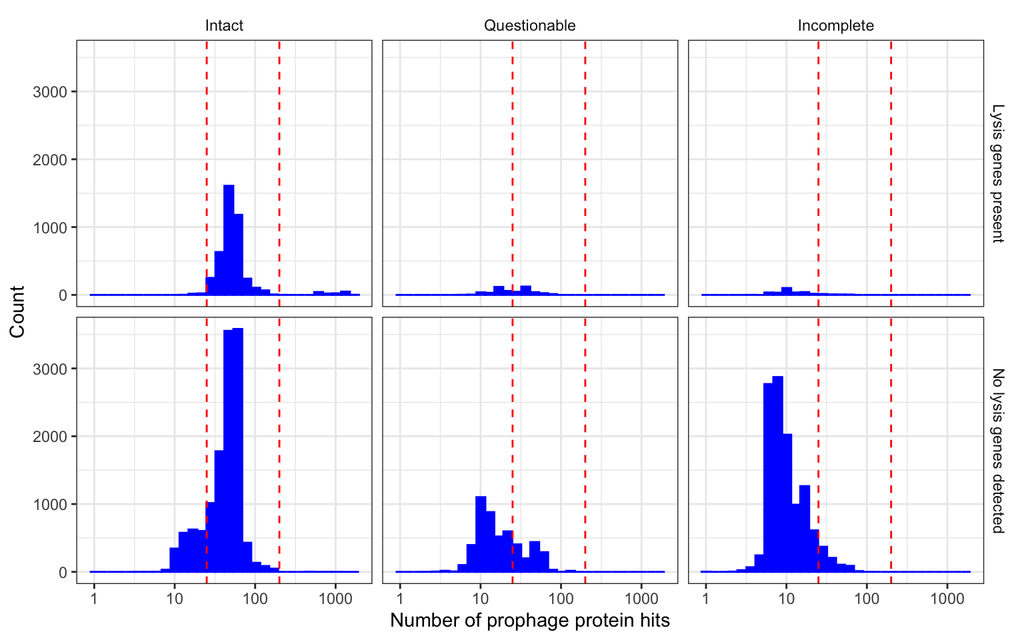

```r
# Plot output
lower_gene_bound <- 25
upper_gene_bound <- 200
ggplot(all_results %>%
         dplyr::mutate(
           Lytic = dplyr::if_else(lysis == 0,
                                  "No lysis genes detected",
                                  "Lysis genes present")
         ) %>%
         dplyr::mutate(
           COMPLETENESS = factor(str_to_sentence(COMPLETENESS),
                                 levels = c(
                                   "Intact",
                                   "Questionable",
                                   "Incomplete"
                                 )
           )
         ),
       aes(x = PHAGE_HIT_PROTEIN_NUM)) +
  geom_histogram(colour = "blue", fill = "blue") +
  scale_x_log10() +
  ylab("Count") +
  xlab("Number of prophage protein hits") +
  geom_vline(xintercept = c(lower_gene_bound,upper_gene_bound), colour = "red", linetype = 2) +
  facet_grid(Lytic~COMPLETENESS) +
  theme_bw() +
  theme(strip.background = element_blank())
```

### Prepare data for analysis of PHASTER prophage frequencies

```r
# Filter prophage and count per genome
filtered_prophage_count_df <-
  all_results %>%
    dplyr::filter(PHAGE_HIT_PROTEIN_NUM >= lower_gene_bound & PHAGE_HIT_PROTEIN_NUM <= upper_gene_bound & COMPLETENESS == "intact") %>%
    dplyr::group_by(accession) %>%
    dplyr::summarise(phage_count = n()) %>%
    dplyr::ungroup()

# Combine phage counts with species information
filtered_prophage_per_sample_df <-
  filtered_genome_df %>%
    # Set consistent name
    dplyr::group_by(BioSampleAccession) %>%
    dplyr::mutate(Name = dplyr::if_else(SequenceLength==max(SequenceLength),BioSampleName,NA_character_)) %>%
    tidyr::fill(Name, .direction = "updown") %>%
    dplyr::ungroup() %>%
    # Process prophage data
    dplyr::left_join(filtered_prophage_count_df, by = c("Accession" = "accession")) %>%
    dplyr::mutate(phage_count = dplyr::if_else(is.na(phage_count),0,phage_count)) %>%
    dplyr::group_by(BioSampleAccession,Name,species) %>%
    dplyr::summarise(total_phage_count = sum(phage_count)) %>%
    dplyr::ungroup() %>%
    dplyr::group_by(species) %>%
    dplyr::mutate(
      total_obs = n()
    ) %>%
    dplyr::ungroup() %>%
    dplyr::group_by(species,total_phage_count) %>%
    dplyr::mutate(
      obs_prob = n()/total_obs
    ) %>%
    dplyr::ungroup() %>%
    dplyr::left_join(
      enframe(species_name) %>%
        tidyr::unnest(value) %>%
        dplyr::rename(species = value),
      by = "species"
    ) %>%
    dplyr::left_join(
      enframe(display_name) %>%
        tidyr::unnest(value) %>%
        dplyr::rename(display = value),
      by = "name"
    )
```

## Identify genomes for geNomad analysis

Taking the same set of complete genome accession codes, we first obtain the lengths of the complete genomes identified from the NCBI search above:

```bash
for f in */*txt; do DIRNAME=`dirname $f`; BASENAME=`basename $f`; cd $DIRNAME; bsub -M 1000 -R 'select[mem>1000] rusage[mem=1000]' -o download_metadata.o -e download_metadata.e ../download_nuccore_metadata.sh $BASENAME ${BASENAME%txt}accessions; cd ..; done
```

We select up to 200 Biosample IDs for each species in which the replicons’ total length matches that expected for a genome:

```r
set.seed(42)

# Read all .accessions files into a single dataframe
complete_accessions_df <-
  # Gather information on accessions
  list.files(
    path       = "./genomad_analysis/genome_accessions",
    pattern    = "\\.accessions$",
    full.names = TRUE
  ) |>
  set_names() |>
  map(read_tsv,
      col_names     = TRUE,
      col_types     = cols(.default = col_character()),   # read ALL cols as character
      show_col_types = FALSE) |>
  list_rbind(names_to = "filepath") |>
  dplyr::mutate(
    species = str_extract(filepath, "([^/]+)(?=_nuccore_complete\\.accessions$)")
  ) |>
  dplyr::select(species, everything(), -filepath) %>%
  # Get rid of duplicates
  dplyr::group_by(resolved_accession) %>%
  dplyr::mutate(accession_count = n()) %>%
  dplyr::ungroup() %>%
  dplyr::filter(accession_count == 1) %>%
  # Now check on total length
  dplyr::inner_join(read.table("./genomad_analysis/genome_accessions/complete_replicon_lengths.tsv",
                               header = TRUE),
                    by = c("resolved_accession")) %>%
  dplyr::group_by(biosample) %>%
  dplyr::mutate(Total_length = sum(length)) %>%
  dplyr::ungroup() %>%
  # Filter by total length
    dplyr::left_join(
      enframe(lower_length_threshold) %>%
            tidyr::unnest(value) %>%
            dplyr::rename(Lower = value) %>%
        dplyr::left_join(
        enframe(upper_length_threshold) %>%
            tidyr::unnest(value) %>%
            dplyr::rename(Upper = value)
        ) %>%
        dplyr::left_join(enframe(species_name) %>%
                           tidyr::unnest(value) %>%
                           dplyr::rename(species = value),
                             by = "name") %>%
        dplyr::left_join(enframe(display_name) %>%
                           tidyr::unnest(value) %>%
                           dplyr::rename(display = value),
                             by = "name") %>%
        dplyr::mutate(species = gsub(" ","_",species)),
        by = "species"
      ) %>%
  dplyr::filter(Total_length > Lower & Total_length < Upper) |>
  # Mark selected biosamples
  # Step 1: Sample up to 200 unique biosamples per species
  dplyr::group_by(species) |>
  dplyr::mutate(
    selected_biosample = biosample %in% sample(
      unique(biosample),
      size = min(200, n_distinct(biosample))  # take all if fewer than 200
    )
  ) |>
  dplyr::ungroup() |>
  # Step 2: Mark all resolved_accessions belonging to selected biosamples
  dplyr::mutate(
    selected_biosample = dplyr::if_else(selected_biosample, "Selected", "Unselected")
  ) %>%
  # Step 3: Flag WGS shotgun accessions (e.g. QWKQ00000000.2)
  dplyr::mutate(
    is_wgs = str_detect(
      resolved_accession,
      "^[A-Z]{4,8}\\d*0{4,}(\\.\\d+)?$"   # 4-6 letters, digits ending in 4+ zeros, optional version
    )
  ) |>
  # Step 4: Flag biosample as WGS if ANY of its accessions are WGS
  dplyr::group_by(species, biosample) |>
  dplyr::mutate(
    wgs_biosample = any(is_wgs)
  ) |>
  dplyr::ungroup() |>
  # Step 5: Unselect WGS biosamples that were selected
  dplyr::mutate(
    selected_biosample = dplyr::if_else(
      wgs_biosample & selected_biosample == "Selected",
      "Unselected",
      selected_biosample
    )
  ) |>
  # Step 6: For each species, top up from non-WGS unselected biosamples
  dplyr::group_by(species) |>
  dplyr::mutate(
    selected_biosample = {
      # How many selected biosamples do we currently have?
      n_currently_selected <- n_distinct(biosample[selected_biosample == "Selected"])

      # How many do we need to top up?
      n_needed <- max(0, 200 - n_currently_selected)

      # Pool of unselected, non-WGS biosamples to draw replacements from
      replacement_pool <- unique(biosample[
        selected_biosample == "Unselected" & !wgs_biosample
      ])

      # Sample replacements (up to n_needed, or all available if fewer)
      replacements <- if (length(replacement_pool) > 0 && n_needed > 0) {
        sample(replacement_pool, size = min(n_needed, length(replacement_pool)))
      } else {
        character(0)
      }

      # Mark ALL accessions in replacement biosamples as Selected
      dplyr::if_else(
        biosample %in% replacements,
        "Selected",
        selected_biosample
      )
    }
  ) |>
  # Step 7: Propagate selection to ALL accessions in each selected biosample
  dplyr::group_by(species, biosample) |>
  dplyr::mutate(
    selected_biosample = dplyr::if_else(
      any(selected_biosample == "Selected"),
      "Selected",
      "Unselected"
    )
  ) |>
  dplyr::ungroup()

# Write output to enable selection
write.csv(complete_accessions_df %>%
            dplyr::filter(selected_biosample == "Selected") %>%
            dplyr::mutate(Path = paste0(species,"/fasta/",resolved_accession,".fasta")) %>%
            dplyr::pull(Path),
          file = "./genomad_analysis/accession_code_selection.csv",
          quote = FALSE,
          col.names = FALSE,
          row.names = FALSE)

write.csv(complete_accessions_df,
          file = gzfile("./genomad_analysis/accession_code_info.csv.gz"),
          quote = TRUE,
          col.names = FALSE,
          row.names = FALSE)
```

### Filter by genome size

We plot the sizes of these replicons to check they are representative of the species:

```r
# Read processed file
complete_accessions_df <-
  read_csv(gzfile("./genomad_analysis/accession_code_info.csv.gz")) %>%
    dplyr::mutate(no_version_accession = str_remove(resolved_accession, "\\.\\d+$"))
```

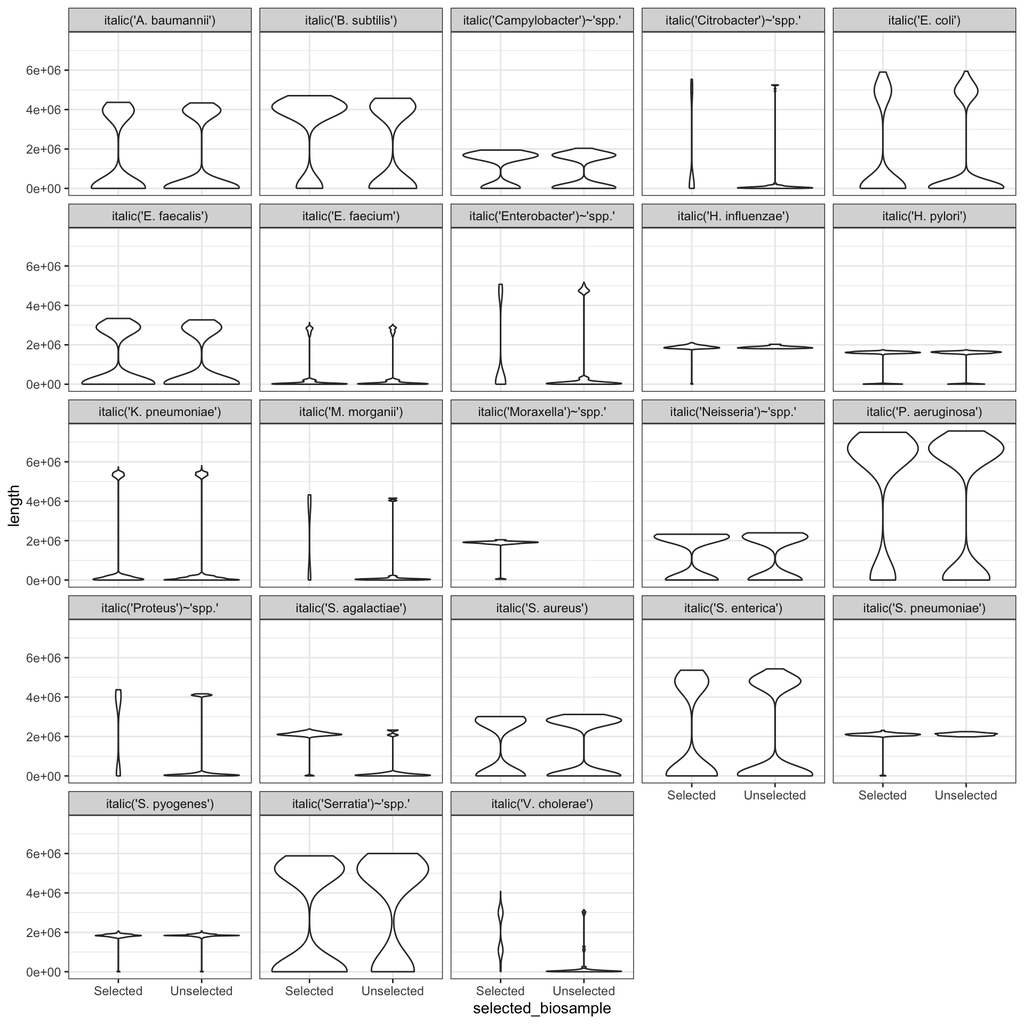

```r
# Plot relative sizes
ggplot(complete_accessions_df,
       aes(x = selected_biosample,
           y = length)) +
  geom_violin() +
  facet_wrap(~display) +
  theme_bw()
```

```bash
mkdir genomad_run
for f in $(cat accession_code_selection.csv); do cp $f genomad_run; done
cd genomad_run
module load PaM/environment
module load genomad/1.12.0

declare -i N; N=1; for FASTA in *fasta; do echo "module load PaM/environment;module load genomad/1.12.0;genomad end-to-end --threads 4 --conservative ${FASTA} ${FASTA%.fasta} c" > genomad_run.$N; chmod +x ./genomad_run.$N; N=($N+1); done
MAX_JOB=`echo $N-1 | bc`
bsub -J geNomad[1-$MAX_JOB] -n 4 -M 24000 -q normal -R 'select[mem>24000] rusage[mem=24000] span[hosts=1]' -o genomad.%I.o -e genome.%I.e ./genomad_run.\${LSB_JOBINDEX}
```

```r
geNomad_selected_accessions <-
  complete_accessions_df %>%
    dplyr::filter(selected_biosample == "Selected") %>%
    dplyr::mutate(no_version_accession = gsub('\\.[0-9]+$','',query_accession)) %>%
    dplyr::pull(no_version_accession)

genomad_results_df <-
  read.table(file = "./genomad_analysis/genomad_virus_summary.tsv",
             comment.char = "",
             header = TRUE,
             sep = "\t") %>%
  dplyr::mutate(no_version_accession = str_remove(accession, "\\.\\d+$")) %>%
  dplyr::filter(no_version_accession %in% complete_accessions_df$no_version_accession) %>%
  dplyr::filter(!grepl("000000", no_version_accession))

accessions_completed <- sum(geNomad_selected_accessions %in% genomad_results_df$no_version_accession)

if (accessions_completed == length(geNomad_selected_accessions)) {
  message("Runs completed")
} else {
  message("Missing runs")
}
```

```
## Runs completed
```

### Identify thresholds for geNomad analysis

Identify prophage densities in species:

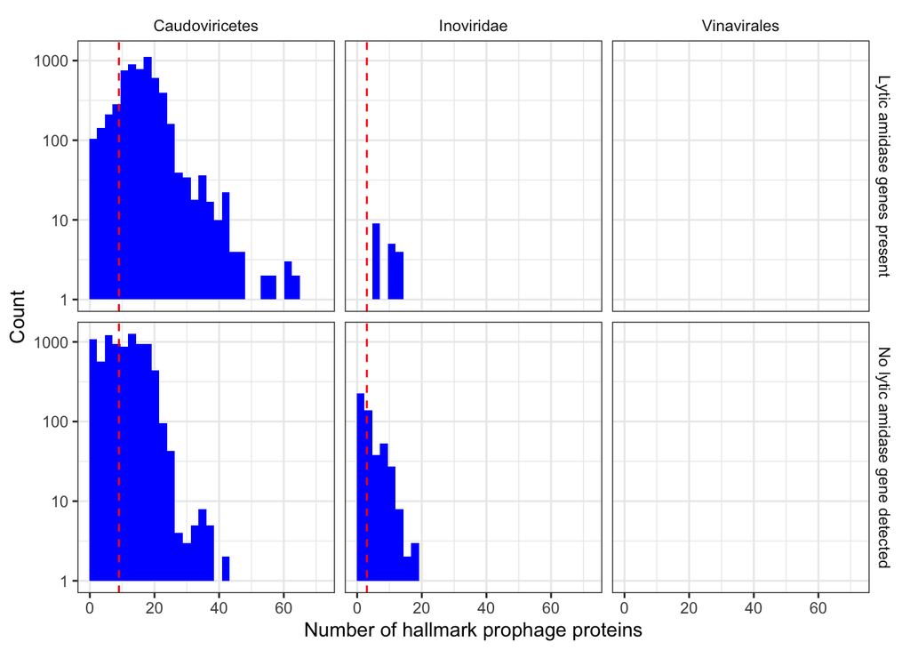

```r
# Threshold for identifying funtional phage
genomad_Caudoviricetes_threshold <- 9
genomad_Inoviridae_threshold <- 3

# Process geNomad prophage output
genomad_phage_df <-
  genomad_results_df %>%
  dplyr::mutate(Classification =
                   dplyr::case_when(
                     is.na(length) ~ NA_character_,
                     grepl("Caudoviricetes",taxonomy) ~ "Caudoviricetes",
                     grepl("Inoviridae",taxonomy) ~ "Inoviridae",
                     grepl("Vinavirales",taxonomy) ~ "Vinavirales",
                     TRUE ~ "Other"
                   )
                ) %>%
  dplyr::left_join(
    read.table("./genomad_analysis/genomad_virus_amidase_lysozyme_counts.tsv",
               header = TRUE) %>%
      dplyr::select(-accession),
    by = "seq_name"
  ) %>%
  dplyr::mutate(Amidase = dplyr::if_else(total_count > 0,"Lytic amidase genes present","No lytic amidase gene detected")) %>%
  dplyr::mutate(Threshold =
                  dplyr::case_when(
                    Classification == "Caudoviricetes" ~ genomad_Caudoviricetes_threshold,
                    Classification == "Inoviridae" ~ genomad_Inoviridae_threshold,
                    TRUE ~ NA_integer_
                  )
                )

# Plot functional information
ggplot(genomad_phage_df %>%
         dplyr::filter(!is.na(length)),
       aes(x = n_hallmarks)) +
  geom_histogram(fill = "blue") +
  facet_grid(Amidase~Classification) +
  geom_vline(data = . %>% dplyr::select(Classification,Threshold) %>% dplyr::distinct(),
             aes(xintercept = Threshold), colour = "red", linetype = 2) +
  scale_y_log10() +
  xlab("Number of hallmark prophage proteins") +
  ylab("Count") +
  theme_bw() +
  theme(strip.background = element_blank())
```

### Distribution of prophage per species

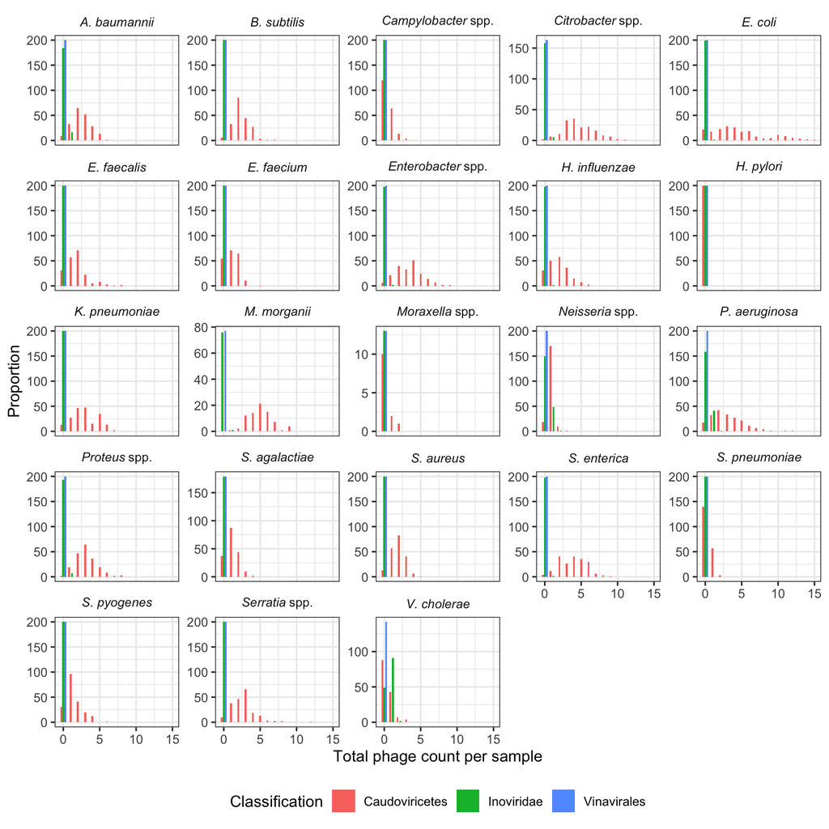

```r
# Define the classification universe once
all_classifications <- genomad_phage_df %>%
  dplyr::filter(!is.na(Classification)) %>%
  dplyr::distinct(Classification)

# Per-accession counts from geNomad
genomad_counts_by_accession_class_df <-
  genomad_phage_df %>%
  dplyr::mutate(
    phage_detected = dplyr::if_else(
      !is.na(length) & !is.na(Threshold) &
        n_hallmarks > Threshold &
        topology == "Provirus",
      1L, 0L
    )
  ) %>%
  dplyr::filter(!is.na(no_version_accession), !is.na(Classification)) %>%
  dplyr::group_by(no_version_accession, Classification) %>%
  dplyr::summarise(phage_count = sum(phage_detected), .groups = "drop")

genomad_phage_by_species_df <-
  complete_accessions_df %>%
  dplyr::filter(selected_biosample == "Selected") %>%
  dplyr::filter(!grepl("000000", no_version_accession)) %>%
  dplyr::distinct(no_version_accession, biosample, species, display, Total_length) %>%
  tidyr::crossing(all_classifications) %>%   # ensures every accession has every Classification
  dplyr::left_join(
    genomad_counts_by_accession_class_df,
    by = c("no_version_accession", "Classification")
  ) %>%
  dplyr::mutate(phage_count = tidyr::replace_na(phage_count, 0L)) %>%
  dplyr::group_by(biosample, species, display, Classification) %>%
  dplyr::summarise(total_phage_count = sum(phage_count), .groups = "drop") %>%
  dplyr::mutate(species = gsub("_", " ", species))

# Plot fitted distributions against observed prophage counts
ggplot() +
  # Observed probabilities as bars
  geom_bar(
    data = genomad_phage_by_species_df,
    aes(x = total_phage_count, fill = Classification),
    #fill = "blue",
    #color = "blue",
    width = 0.8,
    position = position_dodge(preserve = "single")
  ) +
  facet_wrap(~display,
             scales = "free_y",
             labeller = label_parsed) +
  labs(
    x = "Total phage count per sample",
    y = "Proportion"
  ) +
  theme_bw() +
  theme(strip.background = element_blank(),
        legend.position = "bottom")
```

### Analyse plasmids

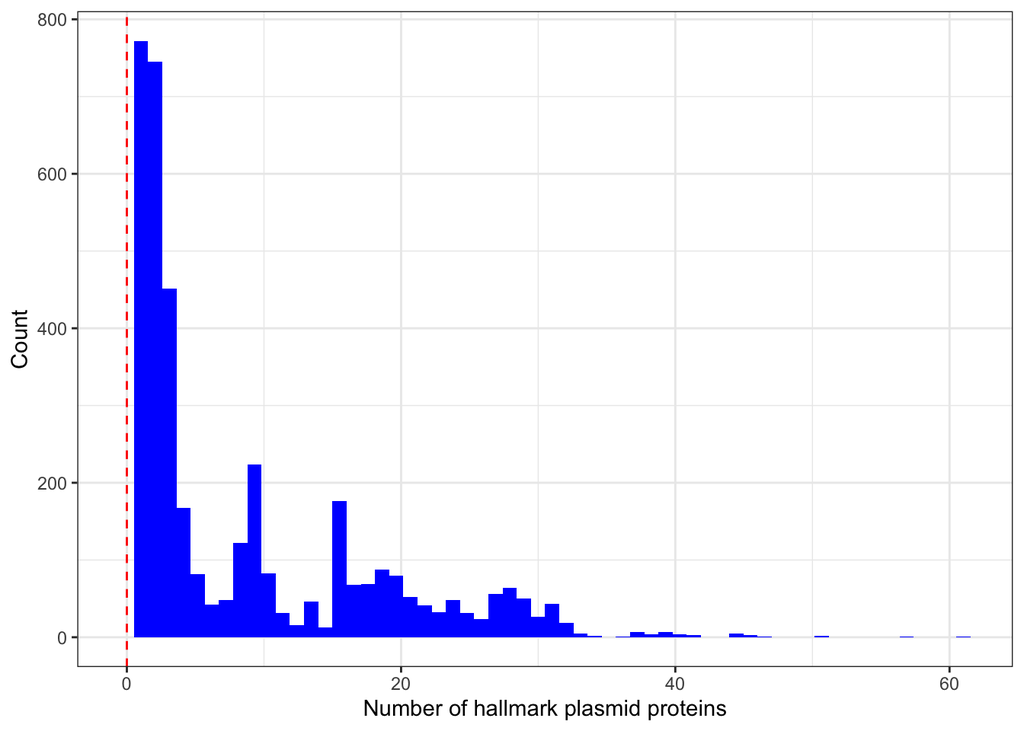

```r
# Process geNomad prophage output
genomad_plasmid_threshold <- 0
genomad_plasmid_df <-
  read.table(file = "./genomad_analysis/tmp_genomad_plasmid_summary.tsv",
             comment.char = "",
             header = TRUE,
             sep = "\t") %>%
  dplyr::mutate(no_version_accession = str_remove(accession, "\\.\\d+$")) %>%
  dplyr::filter(!grepl("000000", no_version_accession)) %>%
  dplyr::filter(no_version_accession %in% complete_accessions_df$no_version_accession) %>%
  dplyr::mutate(Threshold = genomad_plasmid_threshold)

# Plot functional information
ggplot(genomad_plasmid_df %>%
         dplyr::filter(!is.na(length)),
       aes(x = n_hallmarks)) +
  geom_histogram(fill = "blue", bins = 60) +
  xlab("Number of hallmark plasmid proteins") +
  ylab("Count") +
  geom_vline(aes(xintercept = Threshold), colour = "red", linetype = 2) +
  theme_bw() +
  theme(strip.background = element_blank())
```

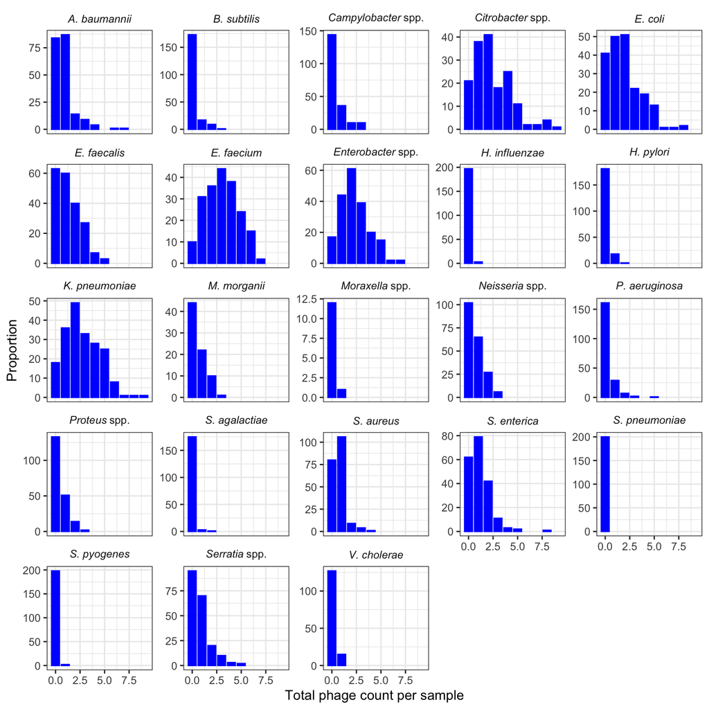

```r
# Per-accession counts from geNomad
genomad_plasmid_counts_by_accession_class_df <-
  genomad_plasmid_df %>%
  dplyr::mutate(
    plasmid_detected = dplyr::if_else(
      !is.na(length) & !is.na(Threshold) &
        n_hallmarks > Threshold,
      1L, 0L
    )
  ) %>%
  dplyr::mutate(Classification = "plasmid") %>%
  dplyr::filter(!is.na(no_version_accession)) %>%
  dplyr::group_by(no_version_accession, Classification) %>%
  dplyr::summarise(plasmid_count = sum(plasmid_detected), .groups = "drop")

all_plasmid_classifications <- "plasmid"

genomad_plasmid_by_species_df <-
  complete_accessions_df %>%
  dplyr::filter(selected_biosample == "Selected") %>%
  dplyr::filter(!grepl("000000", no_version_accession)) %>%
  dplyr::distinct(no_version_accession, biosample, species, display, Total_length) %>%
  tidyr::crossing(Classification = all_plasmid_classifications) %>%   # ensures every accession has every Classification
  dplyr::left_join(
    genomad_plasmid_counts_by_accession_class_df,
    by = c("no_version_accession", "Classification")
  ) %>%
  dplyr::mutate(plasmid_count = tidyr::replace_na(plasmid_count, 0L)) %>%
  dplyr::group_by(biosample, species, display, Classification) %>%
  dplyr::summarise(total_plasmid_count = sum(plasmid_count), .groups = "drop") %>%
  dplyr::mutate(species = gsub("_", " ", species))

# Plot fitted distributions against observed prophage counts
ggplot() +
  # Observed probabilities as bars
  geom_bar(
    data = genomad_plasmid_by_species_df,
    aes(x = total_plasmid_count),
    fill = "blue",
    color = "blue",
    width = 0.8,
    position = position_dodge(preserve = "single")
  ) +
  facet_wrap(~display,
             scales = "free_y",
             labeller = label_parsed) +
  labs(
    x = "Total phage count per sample",
    y = "Proportion"
  ) +
  theme_bw() +
  theme(strip.background = element_blank(),
        legend.position = "bottom")
```

## Analyse distributions across elements

First, combine all the mobile element dataframes:

```r
# PHASTER phage
phaster_phage_counts_long <-
  filtered_prophage_per_sample_df %>%
    dplyr::transmute(
    biosample = BioSampleAccession,
    species,
    display,
    element_type = "prophage",
    count = as.integer(total_phage_count),
    detector = "PHASTER"
  )

# geNomad phage
genomad_phage_counts_long <-
  genomad_phage_by_species_df %>%
  dplyr::transmute(
    biosample,
    species,
    display,
    element_type = Classification,
    count = as.integer(total_phage_count),
    detector = "geNomad"
  )

# geNomad plasmid
genomad_plasmid_counts_long <-
  genomad_plasmid_by_species_df %>%
  dplyr::transmute(
    biosample,
    species,
    display,
    element_type = Classification,
    count = as.integer(total_plasmid_count),
    detector = "geNomad"
  )

# Combine
mobile_counts_long <-
  dplyr::bind_rows(
    genomad_phage_counts_long,
    phaster_phage_counts_long,
    genomad_plasmid_counts_long
  )

poisson_summary_df <-
  fit_poisson_by_species(mobile_counts_long)
```

Poisson fit to prophage from PHASTER:

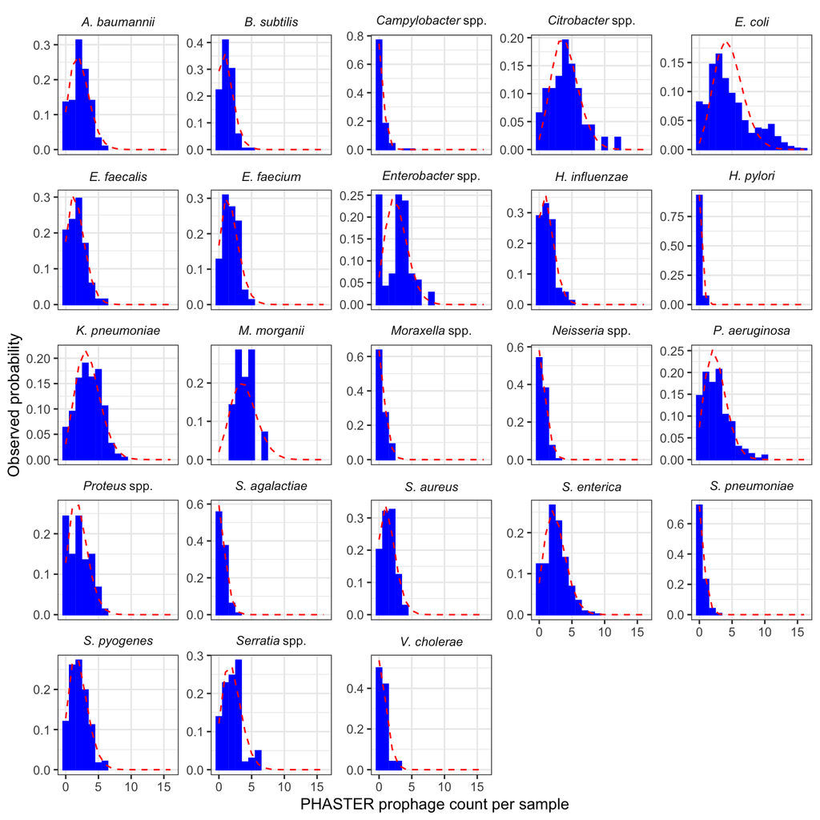

```r
plot_observed_vs_poisson(
  observed_data = mobile_counts_long,
  poisson_summary_data = poisson_summary_df,
  detector_value = "PHASTER",
  element_type_value = "prophage",
  x_label = "PHASTER prophage count per sample"
)$plot
```

These were excluded from the subsequent comparison, to ensure the MLST and prophage data both corresponded to homogeneously behaving populations of isolates.

Poisson fit to plasmid from geNomad:

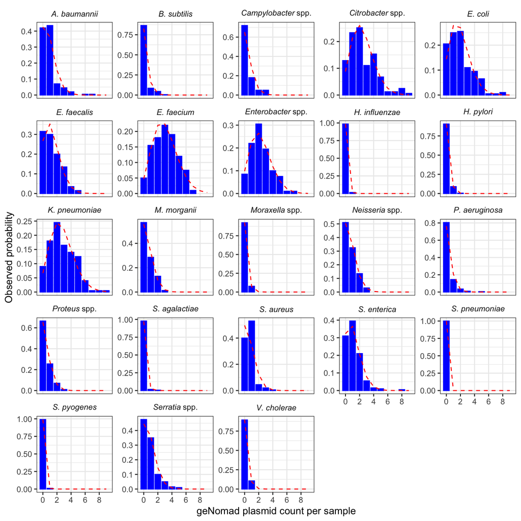

```r
plot_observed_vs_poisson(
  observed_data = mobile_counts_long,
  poisson_summary_data = poisson_summary_df,
  detector_value = "geNomad",
  element_type_value = "plasmid",
  x_label = "geNomad plasmid count per sample"
)$plot
```

Poisson fit to Caudoviricetes from geNomad:

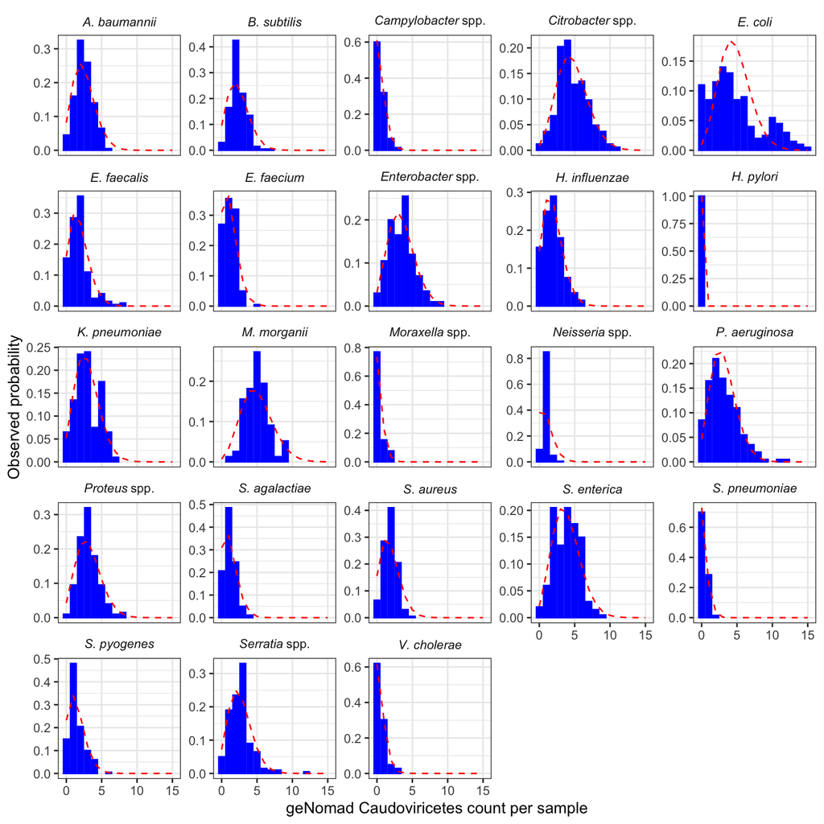

```r
plot_observed_vs_poisson(
  observed_data = mobile_counts_long,
  poisson_summary_data = poisson_summary_df,
  detector_value = "geNomad",
  element_type_value = "Caudoviricetes",
  x_label = "geNomad Caudoviricetes count per sample"
)$plot
```

Poisson fit to Inoviridae from geNomad:

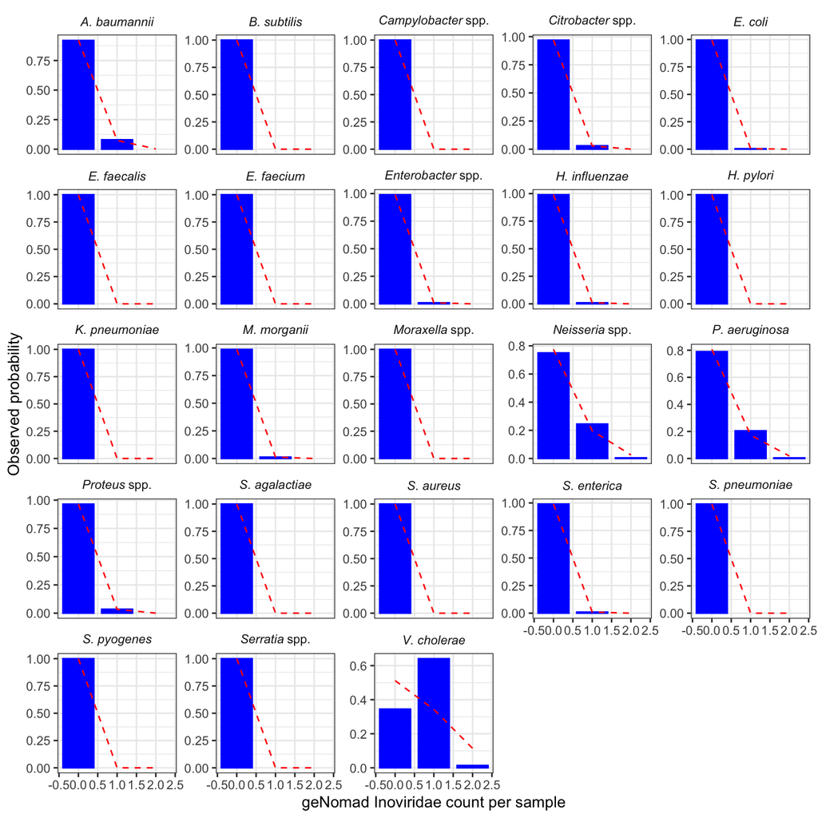

```r
plot_observed_vs_poisson(
  observed_data = mobile_counts_long,
  poisson_summary_data = poisson_summary_df,
  detector_value = "geNomad",
  element_type_value = "Inoviridae",
  x_label = "geNomad Inoviridae count per sample"
)$plot
```

# Compare prophage density and recombination rate

Model the relationship between the density of prophage in genomes and rates of core genome recombination:

```r
# Excluded species
excluded_species <- c("Esp","Psp")

# Combine prophage density with homologous recombination
prophage_rec_df <-
  poisson_summary_df %>%
  dplyr::left_join(
    rec_prob_df %>%
      dplyr::rename(`Recombination probability` = prob) %>%
      dplyr::left_join(tibble::enframe(species_name) %>%
                         tidyr::unnest(value) %>%
                         dplyr::rename(
                           Species = name,
                           species_name = value
                         ),
                       by = "Species") %>%
      dplyr::left_join(tibble::enframe(display_name) %>%
                         tidyr::unnest(value) %>%
                         dplyr::rename(
                           Species = name,
                           display_name = value
                         ),
                       by = "Species") %>%
      # Add transformable status
      dplyr::left_join(enframe(transformable) %>%
                        tidyr::unnest(value) %>%
                        dplyr::rename(Transformability = value),
                       by = c("Species" = "name")) %>%
      # Add ecological status
      dplyr::left_join(enframe(primary_niche) %>%
                        tidyr::unnest(value) %>%
                        dplyr::rename(Niche = value),
                       by = c("Species" = "name")),
    by = c("species"="species_name")
  ) %>%
  # Remove poor Poisson fits
  dplyr::filter(!(Species %in% excluded_species & detector == "PHASTER"))
```

## Fit model to PHASTER outputs

```r
# Fit model to PHASTER output
phaster_model <-
  fit_beta_model(prophage_rec_df,
                 element = "prophage",
                 detector_method = "PHASTER"
                 )

performance::check_model(phaster_model)
```

```
## `check_outliers()` does not yet support models of class `glmmTMB`.
```

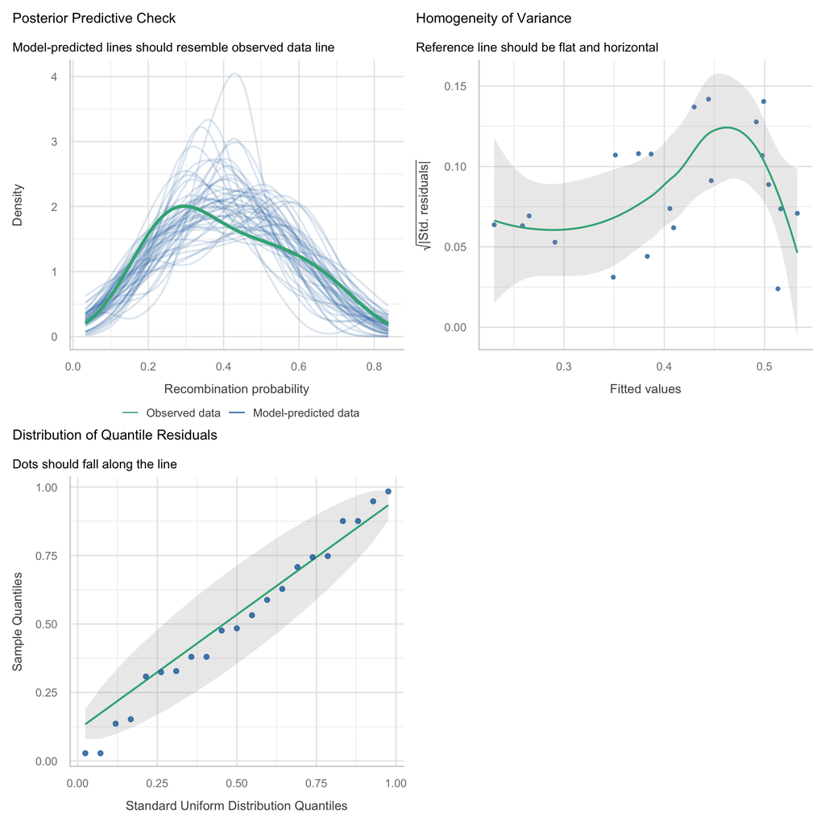

Plot the data and model output together with bacterial species information:

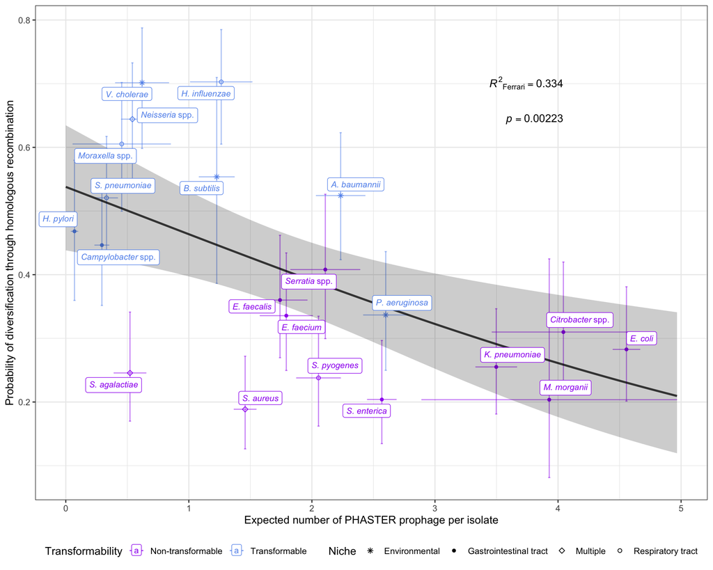

```r
(phaster_comparison_plot <-
  plot_rec_vs_element_model(
    model_fit = phaster_model,
    plot_df = prophage_rec_df,
    detector_value = "PHASTER",
    element_type_value = "prophage",
    x_lab = "Expected number of PHASTER prophage per isolate"
  )$plot
)
```

## Fit model to geNomad Caudoviricetes outputs

```r
# Fit model to PHASTER output
genomad_caudoviricetes_model <-
  fit_beta_model(prophage_rec_df,
                 element = "Caudoviricetes",
                 detector_method = "geNomad"
                 )

performance::check_model(genomad_caudoviricetes_model)
```

```
## `check_outliers()` does not yet support models of class `glmmTMB`.
```

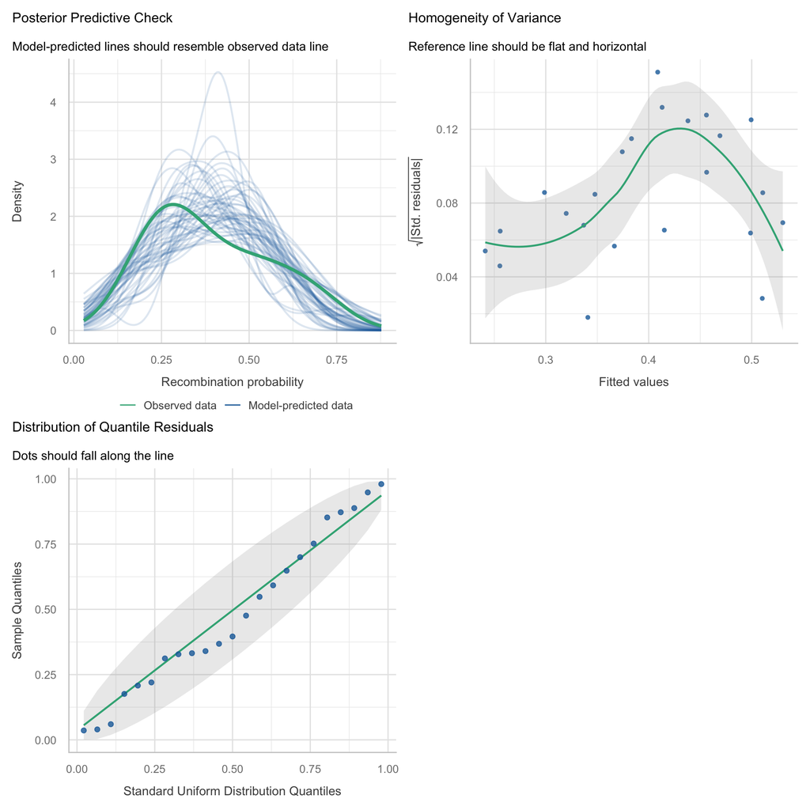

Plot the data and model output together with bacterial species information:

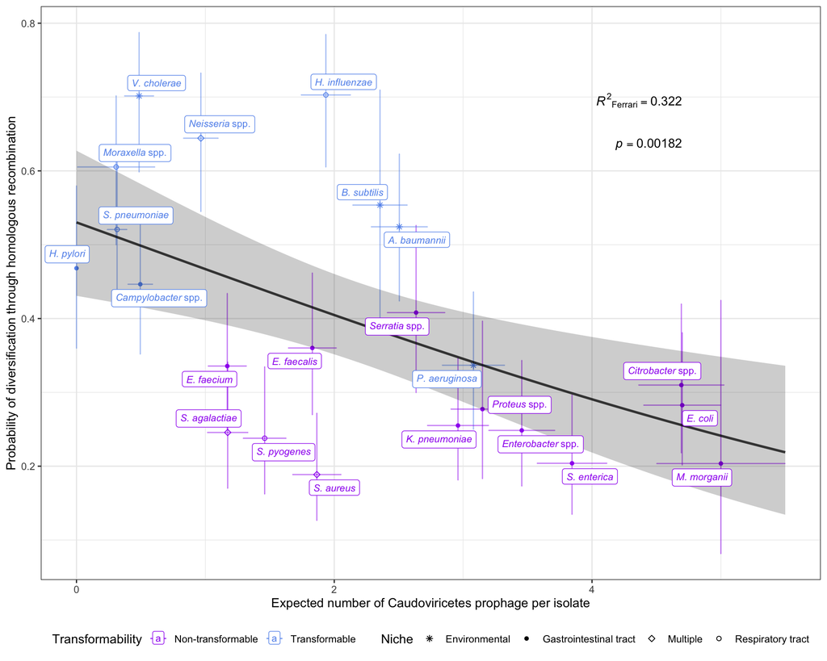

```r
(genomad_comparison_plot <-
  plot_rec_vs_element_model(
    model_fit = genomad_caudoviricetes_model,
    plot_df = prophage_rec_df,
    detector_value = "geNomad",
    element_type_value = "Caudoviricetes",
    x_lab = "Expected number of Caudoviricetes prophage per isolate"
  )$plot
)
```

```r
comparison_plot<-genomad_comparison_plot
```

## Fit model to geNomad Inoviridae outputs

```r
# Fit model to inoviridae output
genomad_inoviridae_model <-
  fit_beta_model(prophage_rec_df,
                 element = "Inoviridae",
                 detector_method = "geNomad"
                 )

performance::check_model(genomad_inoviridae_model)
```

```
## `check_outliers()` does not yet support models of class `glmmTMB`.
```

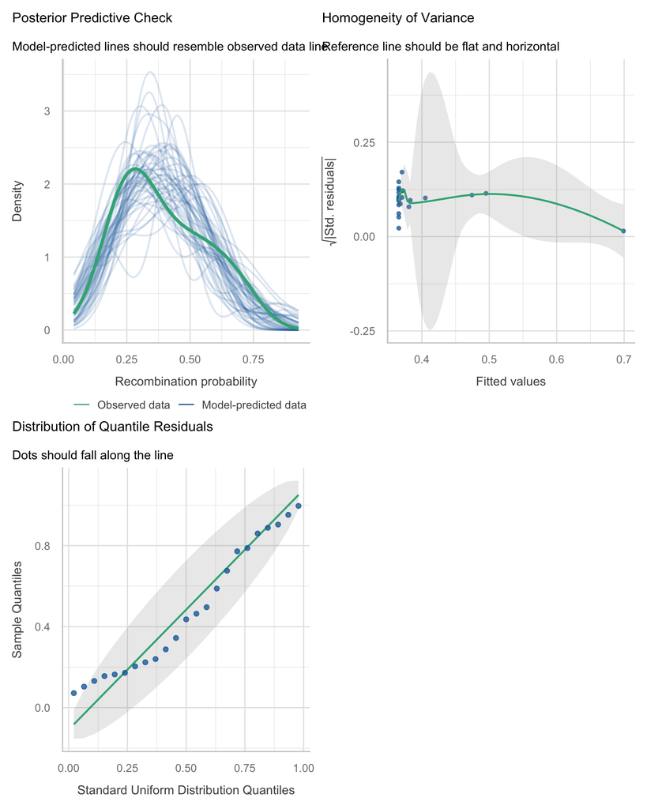

Plot the data and model output together with bacterial species information:

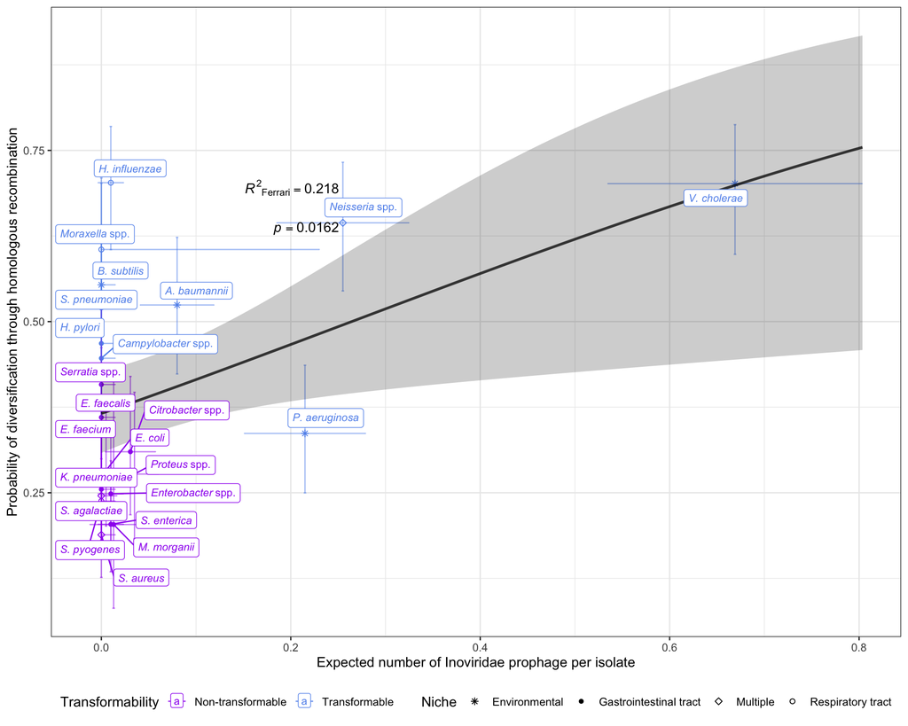

```r
(genomad_inoviridae_comparison_plot <-
  plot_rec_vs_element_model(
    model_fit = genomad_inoviridae_model,
    plot_df = prophage_rec_df,
    detector_value = "geNomad",
    element_type_value = "Inoviridae",
    x_lab = "Expected number of Inoviridae prophage per isolate"
  )$plot
)
```

## Fit model to geNomad plasmid outputs

```r
# Fit model to plasmid output
genomad_plasmid_model <-
  fit_beta_model(prophage_rec_df,
                 element = "plasmid",
                 detector_method = "geNomad"
                 )

performance::check_model(genomad_plasmid_model)
```

```
## `check_outliers()` does not yet support models of class `glmmTMB`.
```

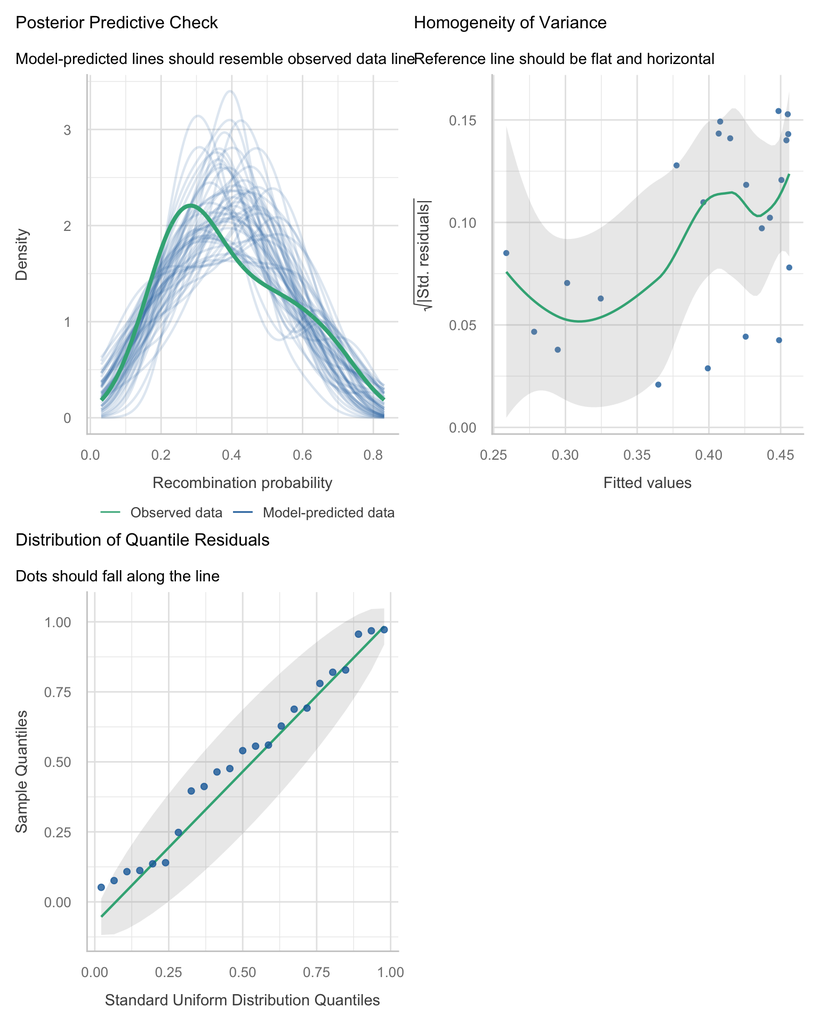

Plot the data and model output together with bacterial species information:

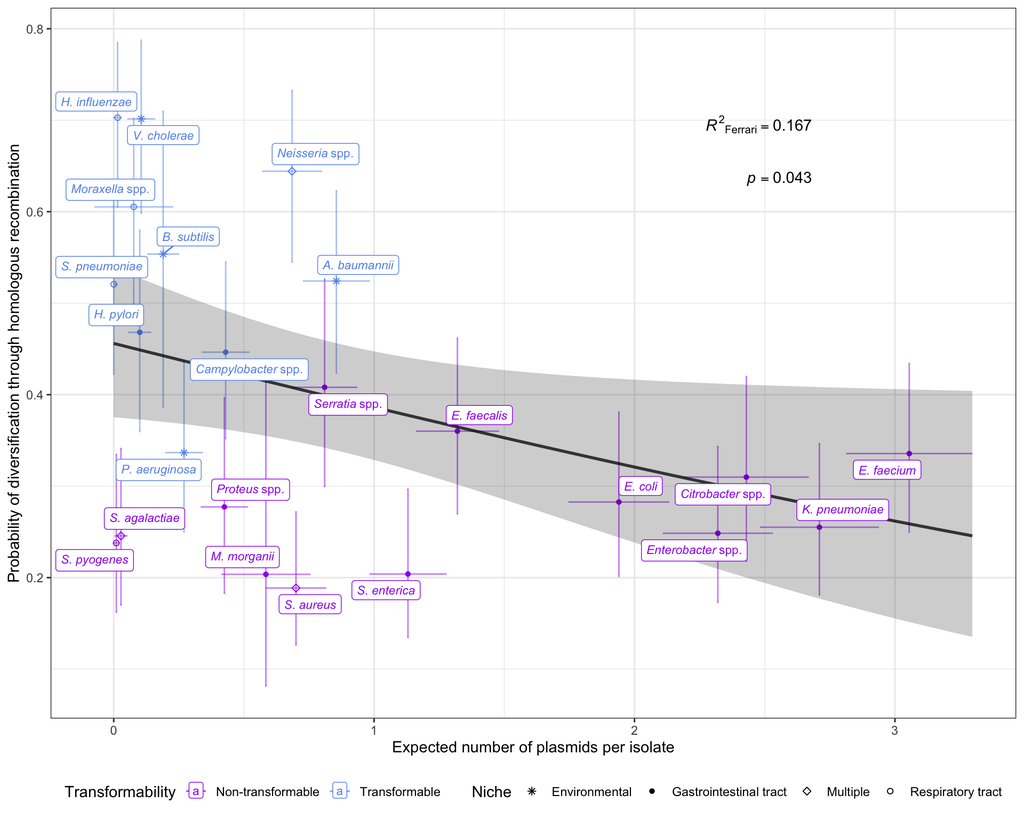

```r
(genomad_plasmid_comparison_plot <-
  plot_rec_vs_element_model(
    model_fit = genomad_plasmid_model,
    plot_df = prophage_rec_df,
    detector_value = "geNomad",
    element_type_value = "plasmid",
    x_lab = "Expected number of plasmids per isolate"
  )$plot
)
```

## Make combined Figure 2

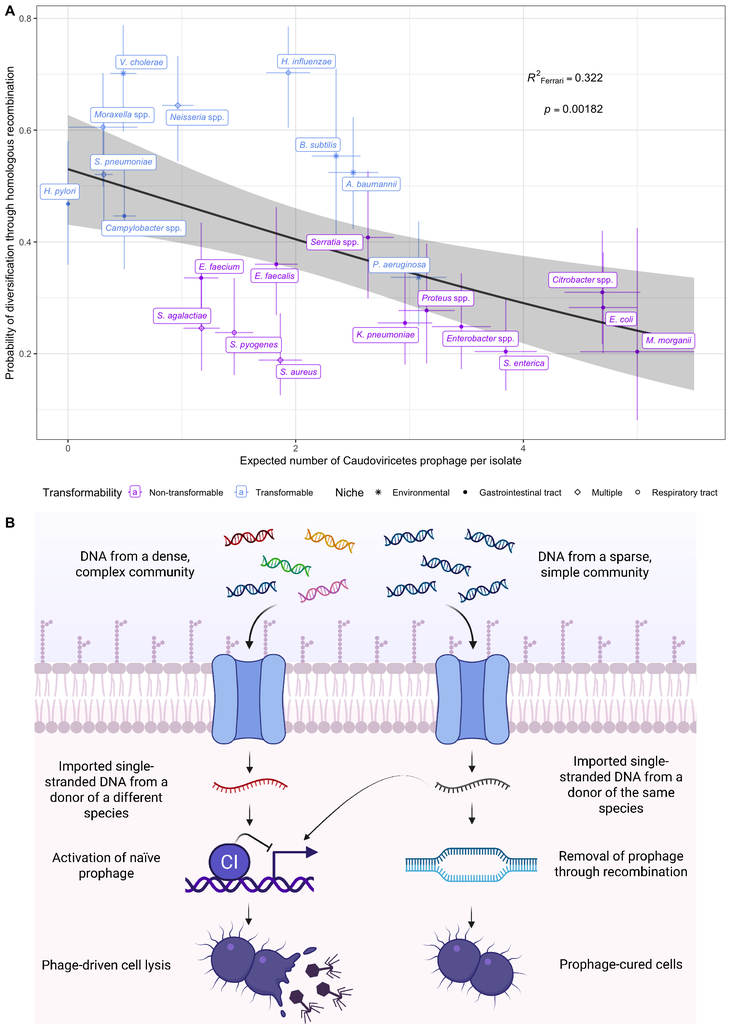

```r
summary_figure <-
  magick::image_ggplot(
    image_crop(
      image_trim(
        image_read_pdf("./summary_figure/recombination-conflict-summary.pdf",
                       density = 600)
      )
    )
  )
cowplot::plot_grid(
  plotlist = list(comparison_plot,
                  summary_figure),
  nrow = 2,
  labels = c("A","B"),
  rel_heights = c(0.5,0.5)
)
```

# Formal test of ecology

Here we formally test the associations between transformability, ecology, recombination and prophage counts:

## Write out ecological information to table

```r
ecological_df <-
  enframe(primary_niche) %>%
    dplyr::mutate(value = unlist(value)) %>%
    dplyr::rename(Niche = value) %>%
    dplyr::left_join(enframe(display_name) %>%
                       dplyr::mutate(Species = unlist(value)) %>%
                       dplyr::select(-value),
                     by= c("name")
                     ) %>%
    dplyr::mutate(Comment =
                    dplyr::case_when(
                      name == "Sau" ~ "Found in nares, skin and gastrointestinal tract",
                      name == "Sag" ~ "Found in gastrointestinal and genital tracts",
                      name == "Nsp" ~ "Meningococci found in nasopharynx; gonococci found in the genital tract",
                      name == "Hpy" ~ "Found in stomach",
                      name == "Spy" ~ "Found in throat",
                      name %in% c("Spn","Hflu","Mcat") ~ "Found in nasopharynx",
                      TRUE ~ ""
                    )
                  ) %>%
  dplyr::select(-name)

clean_species <- function(x) {
  y <- x

  # case 1: italic('...')~'spp.'
  y <- str_replace(
    y,
    "^italic\\('([^']+)'\\)~'spp\\.'$",
    "<i>\\1</i> spp."
  )

  # case 2: italic('...')
  y <- str_replace(
    y,
    "^italic\\('([^']+)'\\)$",
    "<i>\\1</i>"
  )

  y
}

ecological_df %>%
  dplyr::mutate(Species = clean_species(Species)) %>%
  dplyr::select(Species,Niche,Comment) %>%
  knitr::kable(format = "html", escape = FALSE) %>%   # important
  kableExtra::kable_styling(bootstrap_options = "striped", full_width = FALSE)
```

| Species | Niche | Comment |
| --- | --- | --- |
| *E. coli* | Gastrointestinal tract |  |
| *Citrobacter* spp. | Gastrointestinal tract |  |
| *Enterobacter* spp. | Gastrointestinal tract |  |
| *Proteus* spp. | Gastrointestinal tract |  |
| *Serratia* spp. | Gastrointestinal tract |  |
| *S. aureus* | Multiple | Found in nares, skin and gastrointestinal tract |
| *K. pneumoniae* | Gastrointestinal tract |  |
| *S. pneumoniae* | Respiratory tract | Found in nasopharynx |
| *A. baumannii* | Environmental |  |
| *P. aeruginosa* | Environmental |  |
| *E. faecium* | Gastrointestinal tract |  |
| *S. agalactiae* | Multiple | Found in gastrointestinal and genital tracts |
| *S. enterica* | Gastrointestinal tract |  |
| *E. faecalis* | Gastrointestinal tract |  |
| *S. pyogenes* | Respiratory tract | Found in throat |
| *H. influenzae* | Respiratory tract | Found in nasopharynx |
| *M. morganii* | Gastrointestinal tract |  |
| *Neisseria* spp. | Multiple | Meningococci found in nasopharynx; gonococci found in the genital tract |
| *Moraxella* spp. | Respiratory tract |  |
| *Campylobacter* spp. | Gastrointestinal tract |  |
| *H. pylori* | Gastrointestinal tract | Found in stomach |
| *V. cholerae* | Environmental |  |
| *B. subtilis* | Environmental |  |

## Ecological comparison with PHASTER

Plot ecological comparisons with PHASTER results:

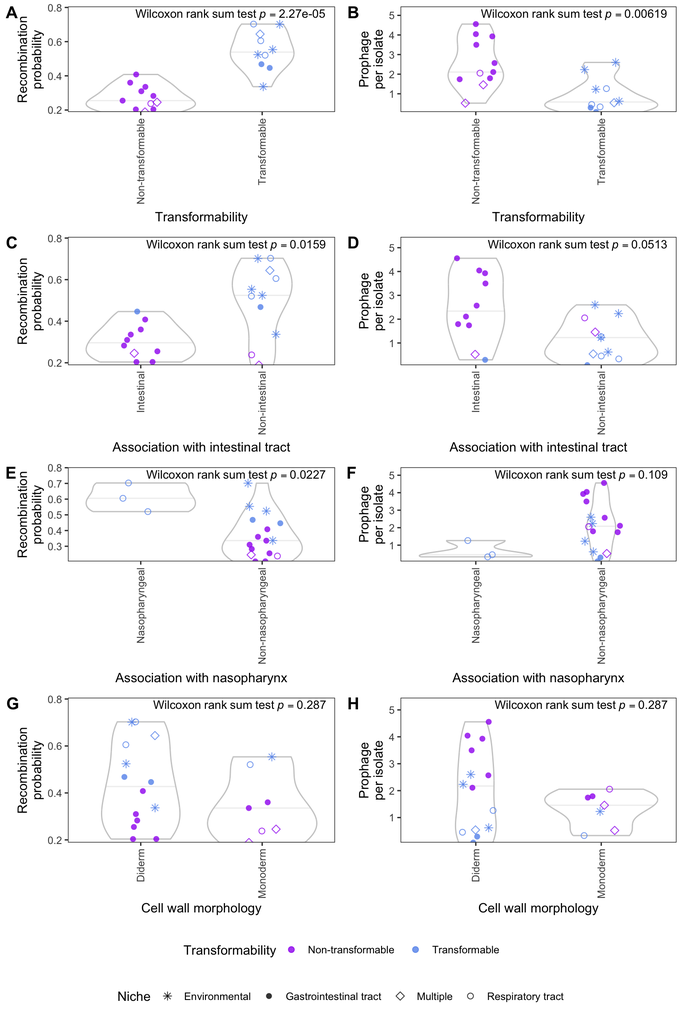

```r
plot_ecology_panel(
  in_df = prophage_rec_df,
  detector_choice = "PHASTER",
  element_choice = "prophage"
)$plot
```

## Ecological comparison of Caudoviricetes with geNomad

Plot ecological comparisons with geNomad results:

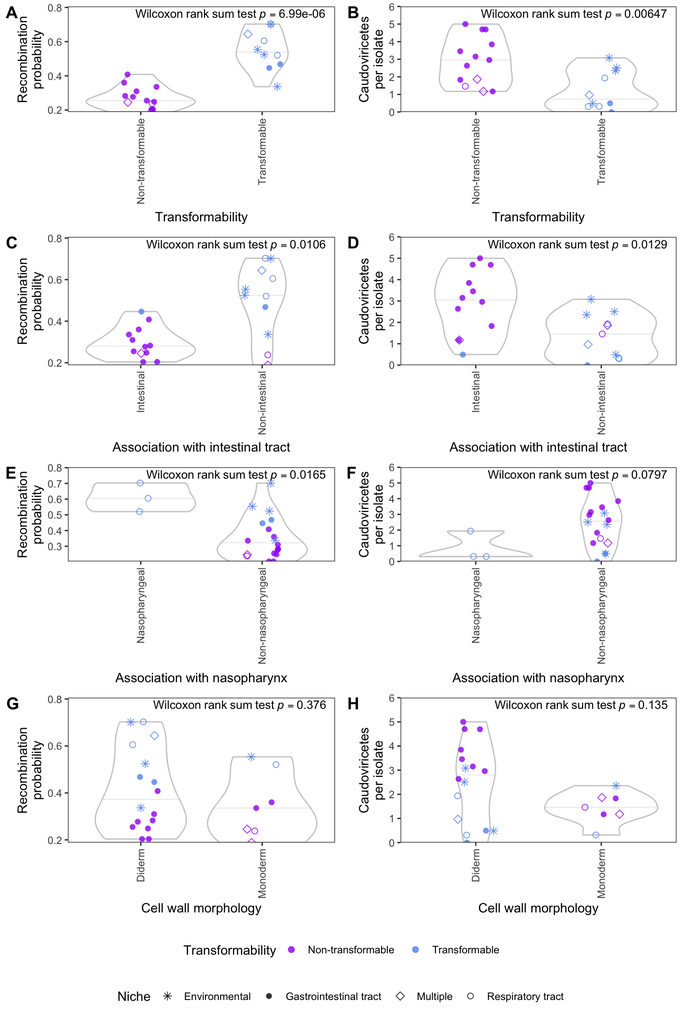

```r
plot_ecology_panel(
  in_df = prophage_rec_df,
  detector_choice = "geNomad",
  element_choice = "Caudoviricetes"
)$plot
```

## Ecological comparison of Inoviridae with geNomad

Plot ecological comparisons with geNomad results:

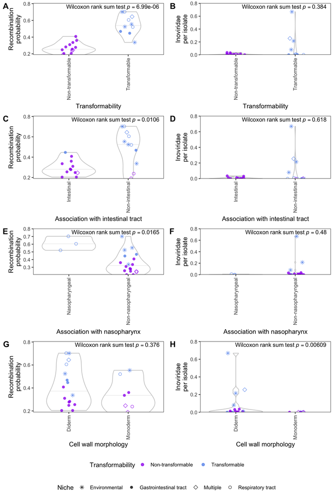

```r
plot_ecology_panel(
  in_df = prophage_rec_df,
  detector_choice = "geNomad",
  element_choice = "Inoviridae"
)$plot
```

## Ecological comparison of plasmids with geNomad

Plot ecological comparisons with geNomad results:

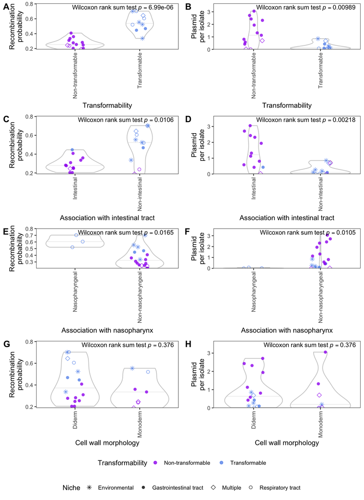

```r
plot_ecology_panel(
  in_df = prophage_rec_df,
  detector_choice = "geNomad",
  element_choice = "plasmid"
)$plot
```

## Tabulate number of processed genomes

```r
# Get summaries of MLST data
st_counts_df <-
  read_csv(file = "./MLST_data/st_counts.csv")
```

```r
# Combine summaries
sample_summary_df <-
  tibble::enframe(table(complete_sequences_df$species)) %>%
    dplyr::rename(`Complete replicons` = value) %>%
    dplyr::left_join(
      tibble::enframe(table(phaster_complete_sequences_df$species)) %>%
        dplyr::rename(`PHASTER entries` = value),
      by = "name"
    ) %>%
    dplyr::left_join(
      st_counts_df,
      by = "name"
    ) %>%
    dplyr::left_join(
      as.data.frame(table(mismatches_df$Species)) %>%
        dplyr::rename(
          name = Var1,
          `Divergent genotypes` = Freq
        ) %>%
        dplyr::left_join(enframe(species_name) %>%
                           tidyr::unnest(value),
                         by = "name") %>%
        dplyr::mutate(name = value) %>%
        dplyr::select(-value),
      by = "name"
    ) %>%
    dplyr::left_join(
      filtered_genome_df %>%
        dplyr::group_by(species) %>%
        dplyr::summarise(`Full-length genomes` = n_distinct(BioSampleAccession)) %>%
        dplyr::ungroup(),
      by = c("name"="species")
    ) %>%
    dplyr::rename(Species = name) %>%
    dplyr::rename(`Full-length genomes analysed with PHASTER` = `Full-length genomes`) %>%
    dplyr::select(Species,`Sequence types`,`Divergent genotypes`,`Complete replicons`,`PHASTER entries`,`Full-length genomes analysed with PHASTER`) %>%
  dplyr::left_join(
    genomad_phage_by_species_df %>%
      dplyr::group_by(biosample) %>%
      dplyr::slice_head(n = 1) %>%
      dplyr::ungroup() %>%
      dplyr::group_by(species) %>%
      dplyr::summarise(`Full-length genomes analysed with geNomad` = n()) %>%
      dplyr::ungroup(),
    by = c("Species"="species")
  )

# Full length genomes used for geNomad
# Read all .accessions files into a single dataframe
full_length_genomes_df <-
  # Gather information on accessions
  list.files(
    path       = "./genomad_analysis/genome_accessions",
    pattern    = "\\.accessions$",
    full.names = TRUE
  ) |>
  set_names() |>
  map(read_tsv,
      col_names     = TRUE,
      col_types     = cols(.default = col_character()),   # read ALL cols as character
      show_col_types = FALSE) |>
  list_rbind(names_to = "filepath") |>
  dplyr::mutate(
    species = str_extract(filepath, "([^/]+)(?=_nuccore_complete\\.accessions$)")
  ) |>
  dplyr::select(species, everything(), -filepath) %>%
  # Get rid of duplicates
  dplyr::group_by(resolved_accession) %>%
  dplyr::mutate(accession_count = n()) %>%
  dplyr::ungroup() %>%
  dplyr::filter(accession_count == 1) %>%
  # Now check on total length
  dplyr::inner_join(read.table("./genomad_analysis/genome_accessions/complete_replicon_lengths.tsv",
                               header = TRUE),
                    by = c("resolved_accession")) %>%
  dplyr::group_by(biosample) %>%
  dplyr::mutate(Total_length = sum(length)) %>%
  dplyr::ungroup() %>%
  # Filter by total length
    dplyr::left_join(
      enframe(lower_length_threshold) %>%
            tidyr::unnest(value) %>%
            dplyr::rename(Lower = value) %>%
        dplyr::left_join(
        enframe(upper_length_threshold) %>%
            tidyr::unnest(value) %>%
            dplyr::rename(Upper = value)
        ) %>%
        dplyr::left_join(enframe(species_name) %>%
                           tidyr::unnest(value) %>%
                           dplyr::rename(species = value),
                             by = "name") %>%
        dplyr::left_join(enframe(display_name) %>%
                           tidyr::unnest(value) %>%
                           dplyr::rename(display = value),
                             by = "name") %>%
        dplyr::mutate(species = gsub(" ","_",species)),
        by = "species"
      ) %>%
  dplyr::filter(Total_length > Lower & Total_length < Upper) %>%
  # Step 3: Flag WGS shotgun accessions (e.g. QWKQ00000000.2)
  dplyr::mutate(
    is_wgs = str_detect(
      resolved_accession,
      "^[A-Z]{4,8}\\d*0{4,}(\\.\\d+)?$"   # 4-6 letters, digits ending in 4+ zeros, optional version
    )
  ) |>
  # Step 4: Flag biosample as WGS if ANY of its accessions are WGS
  dplyr::group_by(species, biosample) |>
  dplyr::mutate(
    wgs_biosample = any(is_wgs)
  ) |>
  dplyr::ungroup() |>
  dplyr::filter(!wgs_biosample) |>         #
  # Final
  dplyr::group_by(species) %>%
  dplyr::summarise(`Full length genomes` = n_distinct(biosample)) %>%
  dplyr::ungroup()
# Generate summary table
sample_summary_df %>%
  dplyr::left_join(full_length_genomes_df %>% dplyr::mutate(Species = gsub("_"," ",species)) %>% dplyr::select(-species), by = "Species") %>%
  dplyr::select(Species,`Sequence types`,`Divergent genotypes`,`Complete replicons`,`Full length genomes`,`Full-length genomes analysed with geNomad`,`PHASTER entries`,`Full-length genomes analysed with PHASTER`) %>%
  kable() %>%
  kable_styling(bootstrap_options = "striped", full_width = FALSE)
```

| Species | Sequence types | Divergent genotypes | Complete replicons | Full length genomes | Full-length genomes analysed with geNomad | PHASTER entries | Full-length genomes analysed with PHASTER |
| --- | --- | --- | --- | --- | --- | --- | --- |
| Acinetobacter baumannii | 3594 | 2117 | 2384 | 883 | 200 | 416 | 214 |
| Bacillus subtilis | 269 | 50 | 527 | 359 | 200 | 284 | 225 |
| Campylobacter spp | 14875 | 11763 | 893 | 521 | 200 | 371 | 317 |
| Citrobacter spp | 1351 | 364 | 710 | 163 | 163 | 78 | 46 |
| Enterobacter spp | 3414 | 1438 | 1816 | 448 | 200 | 129 | 72 |
| Enterococcus faecalis | 2120 | 1355 | 976 | 350 | 200 | 264 | 135 |
| Enterococcus faecium | 3004 | 2421 | 1987 | 351 | 200 | 300 | 149 |
| Escherichia coli | 17505 | 14602 | 15685 | 2501 | 200 | 1853 | 1419 |
| Haemophilus influenzae | 3134 | 2128 | 283 | 247 | 200 | 76 | 76 |
| Helicobacter pylori | 4962 | 331 | 447 | 336 | 200 | 348 | 325 |
| Klebsiella pneumoniae | 9479 | 6605 | 12613 | 2884 | 200 | 675 | 474 |
| Moraxella catarrhalis | 934 | 389 | 14 | 13 | 13 | 12 | 11 |
| Morganella morganii | 141 | 26 | 148 | 77 | 77 | 15 | 14 |
| Neisseria spp | 19195 | 15364 | 592 | 338 | 200 | 259 | 255 |
| Proteus spp | 651 | 268 | 349 | 203 | 200 | 110 | 74 |
| Pseudomonas aeruginosa | 6368 | 3803 | 1642 | 1198 | 200 | 321 | 300 |
| Salmonella enterica | 12873 | 7106 | 4427 | 1860 | 200 | 915 | 697 |
| Serratia spp | 1556 | 383 | 523 | 265 | 200 | 182 | 101 |
| Staphylococcus aureus | 10763 | 9571 | 3241 | 1704 | 200 | 836 | 669 |
| Streptococcus agalactiae | 2410 | 2209 | 209 | 179 | 179 | 132 | 115 |
| Streptococcus pneumoniae | 20436 | 16465 | 262 | 257 | 200 | 151 | 151 |
| Streptococcus pyogenes | 1678 | 1090 | 392 | 383 | 200 | 242 | 242 |
| Vibrio cholerae | 1991 | 554 | 350 | 142 | 142 | 105 | 50 |

## Table of accessions for analysed genomes

```r
# PHASTER output
write.csv(filtered_genome_df %>%
            dplyr::left_join(filtered_prophage_count_df,
                             by = c("Accession" = "accession")) %>%
            dplyr::mutate(phage_count = dplyr::if_else(is.na(phage_count),0,phage_count)) %>%
            dplyr::select(BioSampleAccession,Accession,species,phage_count) %>%
            dplyr::rename(
              Biosample = BioSampleAccession,
              Species = species,
              `Prophage count` = phage_count
            ),
          file = "./prophage/PHASTER_summary.csv",
          row.names = FALSE,
          quote = FALSE
)

# geNomad output
write.csv(complete_accessions_df %>%
            dplyr::filter(selected_biosample == "Selected") %>%
            dplyr::filter(!grepl("000000", no_version_accession)) %>%
            dplyr::distinct(resolved_accession, no_version_accession, biosample, species) %>%
            tidyr::crossing(all_classifications) %>%   # ensures every accession has every Classification
            dplyr::left_join(
              genomad_counts_by_accession_class_df,
              by = c("no_version_accession", "Classification")
            ) %>%
            dplyr::filter(Classification == "Caudoviricetes") %>%
            dplyr::mutate(phage_count = tidyr::replace_na(phage_count, 0L)) %>%
            dplyr::select(biosample,resolved_accession,species,phage_count) %>%
            dplyr::mutate(species = gsub('_',' ',species)) %>%
            dplyr::rename(
              Biosample = biosample,
              Accession = resolved_accession,
              Species = species,
              `Prophage count` = phage_count
            ),
          file = "./prophage/geNomad_summary.csv",
          row.names = FALSE,
          quote = FALSE
)
```

# Experimental data

## Analyse qPCR data

### Parse qPCR data

```r
competence_palette <- c(
  "Spontaneous competence" = "darkolivegreen3",
  "Induced competence" = "seagreen3",
  "Control" = "grey"
)

qpcr_df <-
  read_csv("./experimental_data/complete_qPCR_data.csv") %>%
    dplyr::mutate(`Experimental conditions` =
                    dplyr::case_when(
                      mutants == "NO_CSP" ~ "Control",
                      mutants == "CSP_DnaseI" ~ "Control",
                      mutants == "CSP" ~ "Control",
                      grepl("_CSP",mutants) ~ "Induced competence",
                      TRUE ~ "Spontaneous competence"
                    )
    ) %>%
    dplyr::mutate(DNA =
                    dplyr::case_when(
                      mutants == "NO_CSP" ~ "No CSP or DNA",
                      mutants == "CSP_DnaseI" ~ "CSP and DNase",
                      mutants == "CSP" ~ "CSP, no DNA",
                      grepl("E99",mutants) ~ "1% pneumococcal",
                      grepl("E90",mutants) ~ "10% pneumococcal",
                      grepl("E50",mutants) ~ "50% pneumococcal",
                      grepl("E10",mutants) ~ "90% pneumococcal",
                      grepl("E1",mutants) ~ "99% pneumococcal"
                    )
    ) %>%
  dplyr::mutate(
    Timepoint =
      dplyr::case_when(
        conditions == "2hour" ~ "'2h post-subculture'",
        conditions == "4hour" ~ "'4h post-subculture'"
      )
  ) %>%
  tidyr::pivot_longer(cols = c(Phage_circular,PRCI_circular),
                      names_to = "MGE",
                      values_to = "qPCR") %>%
  dplyr::mutate(
    RMV8_MGE =
      factor(
        dplyr::case_when(
          MGE == "Phage_circular" ~ "phi*'RMV8'",
          MGE == "PRCI_circular" ~ "'PRCI'[italic(malA)]"
        ),
        levels = c("phi*'RMV8'","'PRCI'[italic(malA)]")
      )
  ) %>%
  dplyr::filter(!is.na(qPCR)) %>%
  dplyr::mutate(`Biological replicate` = process_replicates(Replicate)) %>%
  # Adjust for 1.25 ul sampled volume
  dplyr::mutate(qPCR = qPCR/1.25) %>%
  dplyr::mutate(DNA = factor(DNA,
                             levels = c("1% pneumococcal", "10% pneumococcal", "50% pneumococcal", "90% pneumococcal", "99% pneumococcal",
                                        "No CSP or DNA", "CSP and DNase", "CSP, no DNA")
                             )
                ) %>%
  dplyr::mutate(Locus = "attP") %>%
  # Remove replicate with mislabelled CSP that contains rpoA measurements
  dplyr::group_by(`Experimental conditions`,DNA,Timepoint,MGE,`Biological replicate`) %>%
  dplyr::mutate(.idx = row_number()) %>%
  dplyr::ungroup() %>%
  dplyr::group_by(`Experimental conditions`,DNA,Timepoint,MGE,.idx) %>%
  dplyr::arrange(`Biological replicate`, .by_group = TRUE) %>%
  tidyr::fill(rpoA, .direction = "down") %>%
  dplyr::ungroup() %>%
  dplyr::select(-.idx) %>%
  dplyr::filter(`Biological replicate` != "3") %>%
  dplyr::mutate(`Biological replicate` = dplyr::if_else(
    `Biological replicate` == "4",
    "3",
    `Biological replicate`)
  ) %>%
  dplyr::mutate(`Biological replicate` = factor(`Biological replicate`))
```

### Calculate significance of differences between qPCR data

```r
# Keep only DNA percentage conditions of interest
dna_levels <- c("1% pneumococcal", "10% pneumococcal", "50% pneumococcal",
                "90% pneumococcal", "99% pneumococcal")

qpcr_signif_test <- function(in_df, dna_levels) {
  model_df <- in_df %>%
    dplyr::filter(`Experimental conditions` != "Control") %>%
    dplyr::mutate(
      DNA = factor(DNA, levels = dna_levels),
      RMV8_MGE = factor(RMV8_MGE),
      Timepoint = factor(Timepoint),
      `Experimental conditions` = factor(`Experimental conditions`),
      log_qPCR = log10(qPCR)
    )

  nested <- model_df %>%
    dplyr::group_by(RMV8_MGE, Timepoint, `Experimental conditions`) %>%
    tidyr::nest()

  fit_one <- function(dat) {
    dat <- droplevels(dat)
    if (dplyr::n_distinct(dat$DNA) < 2) return(NULL)

    glmmTMB::glmmTMB(
      log_qPCR ~ DNA + (1 | `Biological replicate`),
      data = dat,
      family = gaussian(),
      ziformula = ~0
    )
  }

  nested <- nested %>%
    dplyr::mutate(
      fit = purrr::map(data, fit_one),
      emm = purrr::map(fit, ~ if (is.null(.x)) NULL else emmeans::emmeans(.x, ~ DNA)),
      ctr = purrr::map(emm, ~ if (is.null(.x)) NULL else emmeans::contrast(.x, method = "trt.vs.ctrl", ref = 1)),
      ctr_tbl = purrr::map(ctr, ~ if (is.null(.x)) tibble::tibble() else tibble::as_tibble(summary(.x, infer = TRUE)))
    )

  contrast_df <- nested %>%
    dplyr::select(RMV8_MGE, Timepoint, `Experimental conditions`, ctr_tbl) %>%
    tidyr::unnest(ctr_tbl) %>%
    dplyr::mutate(DNA_comp = stringr::str_extract(contrast, "^[^-]+") %>% stringr::str_trim()) %>%
    dplyr::group_by(RMV8_MGE, Timepoint, `Experimental conditions`) %>%
    dplyr::mutate(p.adj = p.adjust(p.value, method = "holm")) %>%
    rstatix::add_significance(p.col = "p.adj") %>%
    dplyr::ungroup()

  mge_annot_df <- model_df %>%
    dplyr::group_by(RMV8_MGE, Timepoint, `Experimental conditions`, DNA) %>%
    dplyr::summarise(ymax = max(qPCR, na.rm = TRUE), .groups = "drop") %>%
    dplyr::left_join(
      contrast_df %>%
        dplyr::rename(DNA = DNA_comp) %>%
        dplyr::select(RMV8_MGE, Timepoint, `Experimental conditions`, DNA, p.adj, p.adj.signif),
      by = c("RMV8_MGE", "Timepoint", "Experimental conditions", "DNA")
    ) %>%
    dplyr::filter(!is.na(DNA), p.adj < 0.1) %>%
    dplyr::mutate(
      y = dplyr::if_else(
        `Experimental conditions` == "Induced competence",
        max(in_df$qPCR, na.rm = TRUE) * 1.4,
        max(in_df$qPCR, na.rm = TRUE)
      ) * 1.25,
      DNA = factor(DNA, levels = dna_levels)
    )

}

mge_annot_df <- qpcr_signif_test(qpcr_df, dna_levels)
```

### Plot qPCR data

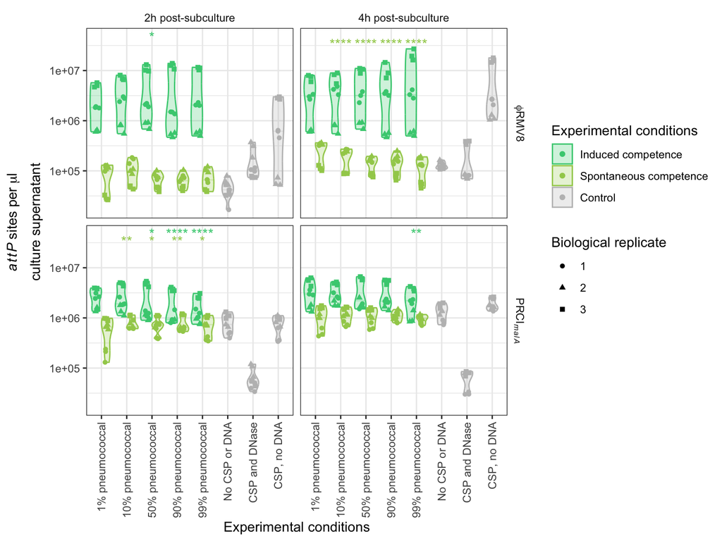

```r
(qpcr_plot <-
  ggplot(qpcr_df,
         aes(x = DNA,
             y = qPCR,
             colour = `Experimental conditions`,
             fill = `Experimental conditions`,
             group = interaction(DNA,`Experimental conditions`),
             shape = `Biological replicate`)) +
    geom_violin(draw_quantiles = c(0.5),
                position = position_dodge(preserve = "single"),
                scale = "width",
                alpha = 0.25) +
    geom_point(position = position_jitterdodge()) +
    scale_colour_manual(values = competence_palette,
                        aesthetics = c("fill","colour")) +
    scale_y_continuous(trans = "log10") +
    ylab(expression(atop(italic(attP)~'sites per'~mu*'l','culture supernatant'))) +
    facet_grid(RMV8_MGE~Timepoint,
               labeller = label_parsed) +
    xlab("Experimental conditions") +
    geom_text(
      data = mge_annot_df %>% dplyr::mutate(qPCR = y, `Biological replicate` = "1"),
      #aes(label = paste0("italic(p)==", signif(p.adj, 2))),
      aes(label = p.adj.signif),
      #parse = TRUE,
      inherit.aes = TRUE,
      size = 4,
      show.legend = FALSE
    ) +
    theme_bw() +
    theme(axis.text.x = element_text(angle = 90, hjust = 1, vjust = 0.5),
          strip.background = element_blank())
)
```

### Contrasts of 1% and 99% pneumococcal DNA experiments

```r
rmv8_decline_df <-
  dplyr::bind_rows(
     qpcr_df %>%
      dplyr::filter(
        `Experimental conditions` == "Spontaneous competence" &
        MGE == "Phage_circular" &
        conditions == "4hour" &
        DNA %in% c("1% pneumococcal","99% pneumococcal")
      ),
    dplyr::bind_rows(
      read_csv("./experimental_data/additional_qPCR_data.csv"),
      read_csv("./experimental_data/Spontaneous_extra_replicates.csv")
    ) %>%
      dplyr::filter(conditions=="4hour") %>%
      dplyr::mutate(`Experimental conditions` = "Spontaneous competence") %>%
      dplyr::mutate(DNA =
                      dplyr::case_when(
                        grepl("E99",mutants) ~ "1% pneumococcal",
                        grepl("E1",mutants) ~ "99% pneumococcal"
                      )
      ) %>%
      tidyr::pivot_longer(cols = c(Phage_circular,PRCI_circular),
                          names_to = "MGE",
                          values_to = "qPCR") %>%
      dplyr::filter(MGE == "Phage_circular") %>%
      dplyr::mutate(`Biological replicate` = process_replicates(Replicate)),
    read_csv("./experimental_data/extra_replicate_spontaneous_qPCR.csv") %>%
      dplyr::filter(conditions=="4hour") %>%
      dplyr::mutate(DNA =
                      dplyr::case_when(
                        grepl("E99",mutants) ~ "1% pneumococcal",
                        grepl("E1",mutants) ~ "99% pneumococcal"
                      )
      ) %>%
      dplyr::mutate(`Experimental conditions` = "Spontaneous competence") %>%
      tidyr::pivot_longer(
        cols = c(Phage_circular,PRCI_circular),
        names_to = "MGE",
        values_to = "qPCR") %>%
        dplyr::mutate(`Biological replicate` = process_replicates(Replicate)) %>%
        dplyr::filter(MGE == "Phage_circular")
    ) %>%
    dplyr::mutate(RMV8_MGE = "phi*'RMV8'",
                  Timepoint = '4h post-subculture')
```

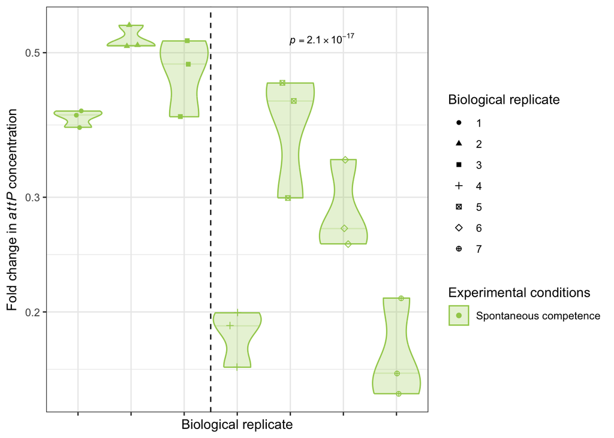

```r
test_res_df <-
  qpcr_signif_test(rmv8_decline_df, c("1% pneumococcal","99% pneumococcal"))

spontaneous_start_end_df <-
  rmv8_decline_df %>%
    dplyr::group_by(DNA,`Biological replicate`,`Experimental conditions`) %>%
    dplyr::mutate(Mean_est = mean(qPCR)) %>%
    dplyr::ungroup() %>%
    dplyr::group_by(DNA) %>%
    dplyr::mutate(Baseline =
                    dplyr::if_else(
                      DNA == "1% pneumococcal",
                      Mean_est,
                      NA_real_
                    )
                  ) %>%
    dplyr::ungroup() %>%
    dplyr::group_by(`Biological replicate`,`Experimental conditions`) %>%
    tidyr::fill(Baseline, .direction = "updown") %>%
    dplyr::mutate(Change = qPCR/Baseline) %>%
    dplyr::ungroup() %>%
    dplyr::filter(DNA == "99% pneumococcal")

# Plot fold changes
replicate_palette <- c(16,17,15,3,7,5,10)
names(replicate_palette) = as.character(1:7)

fmt_p_plotmath <- function(p, digits = 2) {
  if (is.na(p)) return("italic(p)==NA")
  e <- floor(log10(p))
  m <- signif(p / (10^e), digits)
  paste0("italic(p)==", m, "%*%10^", e)
}

(fold_change_plot <-
  ggplot(spontaneous_start_end_df,
         aes(x = `Biological replicate`,
             shape = `Biological replicate`,
             colour = `Experimental conditions`,
             fill = `Experimental conditions`,
             y = Change)) +
    geom_violin(draw_quantiles = c(0.5),
                scale = "width",
                alpha = 0.25) +
    geom_point(position = position_jitter(width = 0.15)) +
    scale_y_continuous(trans = "log10") +
    scale_shape_manual(values = replicate_palette) +
    scale_colour_manual(values = competence_palette,
                        aesthetics = c("fill","colour")) +
    geom_vline(xintercept = 3.5, linetype = 2) +
    ylab(expression("Fold change in"~italic(attP)~"concentration")) +
    geom_text(
      data = test_res_df %>% dplyr::mutate(`Biological replicate` = "6", Change = 0.525),
      aes(label = fmt_p_plotmath(p.adj)),
      colour = "black",
      parse = TRUE,
      inherit.aes = TRUE,
      size = 3,
      show.legend = FALSE,
      nudge_x = -0.4
    ) +
    theme_bw() +
    theme(axis.text.x = element_blank(),
          strip.background = element_rect(fill = NA))
)
```

## Analyse transformation data

### Plot transformation data

Plot transformation data:

```r
transformation_df <-
  dplyr::bind_rows(
    read_csv("./experimental_data/transformation_rates_updated.csv"),
    read_csv("./experimental_data/deletions_with_CSP_three_replicates.csv") %>%
      dplyr::filter(conditions == "Phage_Kan") %>%
      dplyr::select(-conditions) %>%
      dplyr::mutate(mutants = gsub("_","+",donor)) %>%
      dplyr::rename(deletion_rates = Transformation_efficiency),
    read_csv("./experimental_data/spontaneous_transformation_additional_replicates.csv") %>% dplyr::select(-Timepoint)
  ) %>%
  dplyr::mutate(DNA =
                    dplyr::case_when(
                      mutants == "Control" ~ "No CSP or DNA",
                      mutants == "CSP_DnaseI" ~ "CSP and DNase",
                      mutants == "CSP" ~ "CSP, no DNA",
                      grepl("E99",mutants) ~ "1% pneumococcal",
                      grepl("E90",mutants) ~ "10% pneumococcal",
                      grepl("E50",mutants) ~ "50% pneumococcal",
                      grepl("E10",mutants) ~ "90% pneumococcal",
                      grepl("E1",mutants) ~ "99% pneumococcal"
                    )
    ) %>%
    dplyr::mutate(DNA = factor(DNA,
                                 levels = c("1% pneumococcal", "10% pneumococcal", "50% pneumococcal", "90% pneumococcal", "99% pneumococcal",
                                            "No CSP or DNA", "CSP and DNase", "CSP, no DNA")
                                 )
                    ) %>%
    dplyr::mutate(`Experimental conditions` =
                    dplyr::case_when(
                      mutants == "Control" ~ "Control",
                      mutants == "CSP_DnaseI" ~ "Control",
                      mutants == "CSP" ~ "Control",
                      grepl("CSP",mutants) ~ "Induced competence",
                      TRUE ~ "Spontaneous competence"
                    )
    ) %>%
    dplyr::group_by(DNA,`Experimental conditions`) %>%
    dplyr::mutate(`Biological replicate` = as.character(row_number())) %>%
    dplyr::ungroup()
```

### Calculate significance of differences between transformation data

```r
analysis_df <- transformation_df %>%
  dplyr::filter(`Experimental conditions` != "Control") %>%
  dplyr::filter(DNA %in% dna_levels) %>%
  dplyr::mutate(
    DNA = factor(DNA, levels = dna_levels),
    # optional log transform for plotting/interpretability
    log_rate = log10(deletion_rates + 1e-8)
  )

# Wilcoxon tests vs reference (1%) within each condition
wilcox_results <- analysis_df %>%
  dplyr::group_by(`Experimental conditions`) %>%
  rstatix::wilcox_test(
    log_rate ~ DNA,
    ref.group = "1% pneumococcal"
  ) %>%
  rstatix::adjust_pvalue(method = "holm") %>%
  rstatix::add_significance("p.adj") %>%
  dplyr::ungroup()

# y positions by condition x DNA for clean label placement
y_pos_df <- analysis_df %>%
  dplyr::mutate(y = dplyr::if_else(`Experimental conditions` == "Induced competence",
                max(deletion_rates, na.rm = TRUE) * 1.75,
                max(deletion_rates, na.rm = TRUE) * 1.15
                )
)

# Calculate annotation positions
transf_annot_df <- wilcox_results %>%
  dplyr::mutate(
    DNA = group2,
    ref = group1
  ) %>%
  dplyr::left_join(
    y_pos_df,
    by = c("Experimental conditions", "DNA")
  ) %>%
  dplyr::filter(!is.na(p.adj.signif), p.adj.signif != "ns") %>%
  dplyr::mutate(label = p.adj.signif)
```

### Plot transformation data

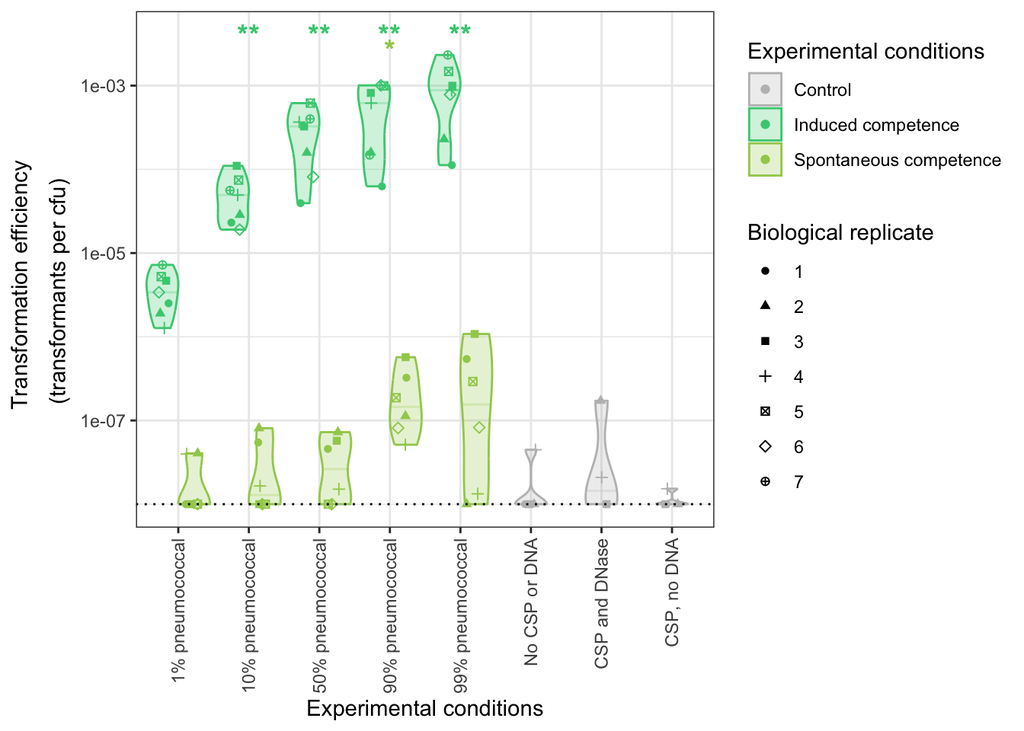

```r
(transformation_plot <- ggplot(
  transformation_df,
  aes(
    x = DNA,
    y = deletion_rates + 1e-8,
    colour = `Experimental conditions`,
    fill = `Experimental conditions`,
    shape = `Biological replicate`,
    group = interaction(mutants, `Experimental conditions`)
  )
) +
  geom_violin(
    draw_quantiles = c(0.5),
    position = position_dodge(preserve = "single"),
    scale = "width",
    alpha = 0.25
  ) +
  geom_point(position = position_jitterdodge()) +
  ylab(expression(atop("Transformation efficiency     ", "(transformants per cfu)       "))) +
  scale_colour_manual(values = competence_palette, aesthetics = c("fill", "colour")) +
  scale_shape_manual(values = replicate_palette) +
  scale_y_continuous(trans = "log10") +
  xlab("Experimental conditions") +
  geom_hline(yintercept = 1e-8, linetype = 3) +
  theme_bw() +
  theme(
    axis.text.x = element_text(angle = 90, hjust = 1, vjust = 0.5),
    strip.background = element_rect(fill = NA)
  ) +
  # significance labels (non-control only)
  geom_text(
    data = transf_annot_df,
    aes(
      x = DNA,
      y = y,
      label = label,
      colour = `Experimental conditions`
    ),
    inherit.aes = FALSE,
    size = 5,
    show.legend = FALSE
  )
)
```

Combine experimental data into a single figure:

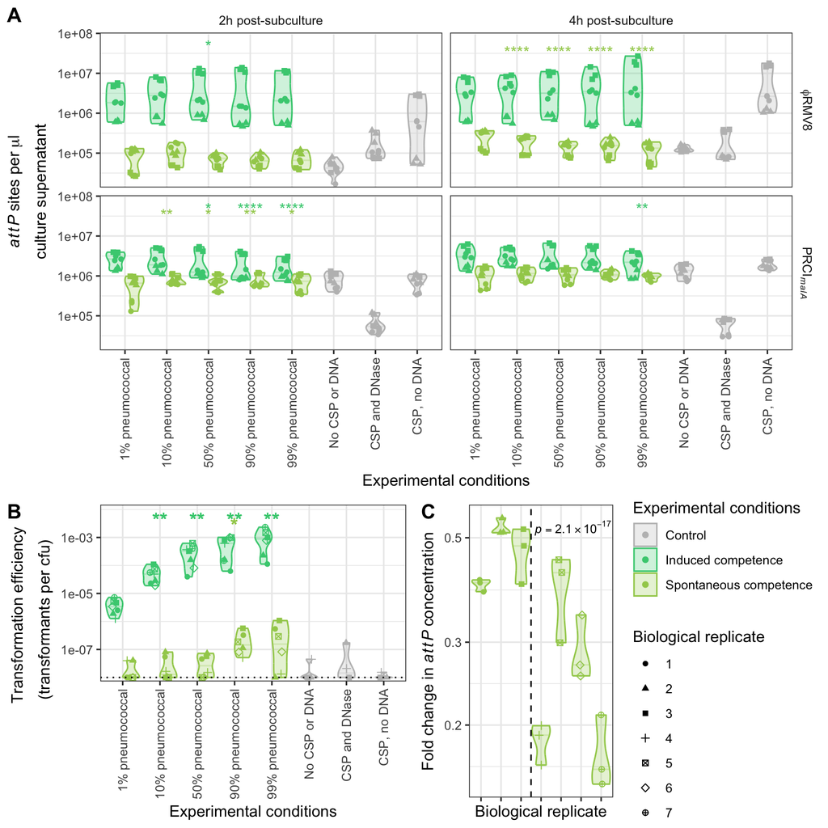

```r
legend_plot <-
  cowplot::get_legend(transformation_plot)
# Fix axes
qpcr_plot <-
  qpcr_plot +
  scale_y_continuous(
    trans = "log10",
    expand = expansion(mult = c(0.025, 0.1))
  )
# Fix axes
transformation_plot <-
  transformation_plot +
  scale_y_continuous(
    trans = "log10",
    expand = expansion(mult = c(0.025, 0.1))
  )
bottom_right_plot <-
  cowplot::plot_grid(plotlist = list(fold_change_plot +
                                       theme(legend.position = "none"),
                                     legend_plot),
                                     nrow = 1,
                                     labels = c("C","")
                     )

bottom_plots <-
  cowplot::plot_grid(plotlist = list(transformation_plot +
                                       theme(legend.position = "none",
                                             axis.title.y = element_text(hjust = 1,
                                                                         vjust = 0)),
                                     bottom_right_plot),
                     labels = c("B",""),
                     nrow = 1,
                     rel_widths = c(0.5,0.5))
(exp_plot <-
  cowplot::plot_grid(plotlist = list(qpcr_plot +
                                       theme(legend.position = "none"),
                                     bottom_plots),
                     labels = c("A",""),
                     nrow = 2,
                     rel_heights = c(1.5,1))
)
```